# High-Dimensional Regression

**Track:** T2 Supervised Learning · **Difficulty:** advanced · **Prereqs:** Kernel Regression, Local Polynomial Regression, `concentration-inequalities`, `convex-analysis`, `gradient-descent`

This notebook is the source of truth for the math, code, and figures behind the **High-Dimensional Regression** topic on formalML. Markdown cells carry the exposition (definitions, theorems, proofs); code cells validate the math numerically and produce the figures. The brief at `docs/plans/formalml-high-dimensional-regression-handoff-brief.md` is the implementation spec; this notebook is what gets executed.

Code is CPU-only NumPy / SciPy / scikit-learn. End-to-end runtime target: under 60 seconds on a 2020-era laptop.

```python
# Preamble — imports, RNG, plot style, output directory.
# formalML notebook conventions (matches kernel-regression, local-regression,
# sparse-bayesian-priors): May-2026 figure-styling baseline; deep-blue / red /
# brown / gray palette; OUT_DIR for figure exports; single seeded RNG threaded
# through the notebook.

from __future__ import annotations
from pathlib import Path

import numpy as np
import matplotlib as mpl
import matplotlib.pyplot as plt
from sklearn.linear_model import (
    Lasso, LassoCV, LassoLarsIC, Ridge, ElasticNet, ElasticNetCV,
    LogisticRegression,
)

# --- Reproducibility -------------------------------------------------------
SEED = 42
rng = np.random.default_rng(SEED)

# --- Figure styling — May-2026 formalML baseline ---------------------------
COLOR_OLS       = "#7f7f7f"  # gray  — naive / unregularized baseline
COLOR_RIDGE     = "#7b3c10"  # brown — L2 / classical regularizer
COLOR_LASSO     = "#1f4e79"  # deep blue — central object of this topic
COLOR_ENET      = "#3a6e3a"  # forest — elastic net
COLOR_DEBIASED  = "#c0504d"  # red   — debiased / one-step-corrected estimator
COLOR_TRUTH     = "#000000"  # black — beta* / oracle / target
COLOR_TRAIN     = "#7f7f7f"
COLOR_TEST      = "#1f4e79"

mpl.rcParams.update({
    "figure.dpi": 110,
    "savefig.dpi": 200,
    "figure.figsize": (7.0, 4.0),
    "axes.spines.top": False,
    "axes.spines.right": False,
    "axes.labelsize": 11,
    "axes.titlesize": 12,
    "axes.titleweight": "bold",
    "axes.titlepad": 10,
    "legend.frameon": False,
    "legend.fontsize": 10,
    "xtick.labelsize": 10,
    "ytick.labelsize": 10,
    "font.family": "DejaVu Sans",
    "mathtext.fontset": "cm",
})

# --- Output directory for figures ------------------------------------------
OUT_DIR = Path("figures")
OUT_DIR.mkdir(parents=True, exist_ok=True)

# --- DGP-1: the canonical sparse high-dimensional design --------------------
# n = 200, p = 500, s = 10. Rows X_i iid N(0, Sigma) with AR(1) Toeplitz
# Sigma_jk = 0.5^|j-k| (weakly decaying correlation). beta* has the first
# 10 entries equal to 1, the rest 0. Noise sigma = 0.5 => population R^2 ~ 0.99.
# Reused across sections 2-9.

def make_dgp1(n=200, p=500, s=10, sigma=0.5, rho=0.5, rng=None):
    """Generate the canonical sparse high-dimensional DGP for this topic.

    Returns (X, y, beta_star, Sigma).
    """
    rng = rng if rng is not None else np.random.default_rng(SEED)
    idx = np.arange(p)
    Sigma = rho ** np.abs(np.subtract.outer(idx, idx))    # AR(1) Toeplitz
    L = np.linalg.cholesky(Sigma)
    Z = rng.standard_normal((n, p))
    X = Z @ L.T
    beta_star = np.zeros(p)
    beta_star[:s] = 1.0
    eps = sigma * rng.standard_normal(n)
    y = X @ beta_star + eps
    return X, y, beta_star, Sigma

# Generate the section 1 sample (referenced as X1, y1, beta_star_1 throughout sections 2-9).
X1, y1, beta_star_1, Sigma_1 = make_dgp1(rng=np.random.default_rng(SEED))

# Sanity: print shape + empirical R^2 (theoretical ~ 0.99 for AR(1) Toeplitz
# with rho=0.5, s=10 active block, sigma=0.5).
signal_var = float(np.var(X1 @ beta_star_1))
noise_var  = 0.5 ** 2
r2_pop = signal_var / (signal_var + noise_var)
print(f"DGP-1: n={X1.shape[0]}, p={X1.shape[1]}, "
      f"s={int((beta_star_1 != 0).sum())}, "
      f"empirical signal-R^2 ~ {r2_pop:.3f}")
```

```
DGP-1: n=200, p=500, s=10, empirical signal-R^2 ~ 0.991
```

## §1. From OLS to penalized regression

When the predictor matrix has more columns than rows, ordinary least squares stops being a single estimator and becomes a degenerate family — infinitely many vectors fit the training data perfectly, none of them generalize. This section establishes the high-dimensional regime, shows OLS failing on the canonical sparse-Gaussian-design problem we'll reuse for the next eight sections, and introduces the two classical regularization remedies: ridge (L2-penalized) and lasso (L1-penalized).

Ridge gives a unique solution and shrinks every coefficient smoothly toward zero. Lasso gives a sparse solution and shrinks small coefficients all the way to zero. The geometric difference between those two penalties — corners on the L1 ball, smooth curvature on the L2 ball — is what makes the lasso the central object of this topic.

### §1.1 The high-dimensional regime $p \gtrsim n$ and where it appears

Standard regression theory assumes more observations than features ($n > p$), often by orders of magnitude. The high-dimensional regime flips that: $p$ is comparable to or much larger than $n$. Three places it shows up routinely:

- **Genome-wide association studies (GWAS):** regress a phenotype on hundreds of thousands to millions of single-nucleotide polymorphisms ($p \approx 10^6$, $n \approx 10^4$).
- **Functional MRI:** predict a behavioral or clinical outcome from $\sim 10^5$ voxel-level activations across $n \sim 10^2$ scans.
- **Text and high-cardinality categorical features:** a bag-of-words encoding pushes $p$ into the millions while $n$ stays in the thousands.

These problems share more than $p \gg n$ — they're also **sparse**: only a small subset of features carries the actual signal. A handful of SNPs drive most of the heritable variation in a quantitative trait; a focal brain region carries most of the predictive signal; a few keywords carry most of the topic information.

We'll formalize sparsity as $\|\boldsymbol\beta^*\|_0 = s$ where $s \ll p$ — the true coefficient vector $\boldsymbol\beta^* \in \mathbb{R}^p$ has only $s$ nonzero entries. The set $S = \{j : \beta^*_j \neq 0\}$ is the **support** and $|S| = s$ is the **sparsity level**. We don't know $S$ in advance; recovering it (or, more modestly, predicting well without recovering it) is the estimator's job.

### §1.2 Why OLS fails: the rank-deficient normal equations

OLS minimizes the squared training loss

$$ \hat{\boldsymbol\beta}^{\text{OLS}} = \arg\min_{\boldsymbol\beta \in \mathbb{R}^p} \frac{1}{n} \|\mathbf{y} - \mathbf{X} \boldsymbol\beta\|_2^2, $$

with closed form $\hat{\boldsymbol\beta}^{\text{OLS}} = (\mathbf{X}^\top \mathbf{X})^{-1} \mathbf{X}^\top \mathbf{y}$ when $\mathbf{X}^\top \mathbf{X}$ is invertible. Invertibility requires $\text{rank}(\mathbf{X}) = p$, which in turn requires $n \ge p$.

When $p > n$, $\mathbf{X}^\top \mathbf{X}$ has rank at most $n < p$ and is singular. The normal equations have infinitely many solutions: any vector in the $(p - n)$-dimensional null space of $\mathbf{X}$ can be added to a solution without changing the residual. The OLS objective has a flat plateau of global minima, all interpolating the training data exactly.

The standard pseudoinverse fix picks the minimum-norm solution from that plateau:

$$ \hat{\boldsymbol\beta}^{\text{OLS, min-norm}} = \mathbf{X}^\top (\mathbf{X} \mathbf{X}^\top)^{-1} \mathbf{y}. $$

But "minimum-norm OLS" is still OLS — it interpolates the training data ($\mathbf{X} \hat{\boldsymbol\beta} = \mathbf{y}$), training MSE is zero, and test MSE is unbounded. Even before $p$ reaches $n$, predictive performance degrades: as $p \to n$ from below, the smallest singular value of $\mathbf{X}$ approaches zero, $(\mathbf{X}^\top \mathbf{X})^{-1}$ blows up, and the OLS coefficient estimates inflate even though the in-sample fit looks great.

**DGP-1 (the §1 toy, reused across §§2-9).** $n = 200$, $p = 500$, $s = 10$. Rows $\mathbf{x}_i \in \mathbb{R}^p$ iid $\mathcal{N}(\mathbf{0}, \boldsymbol\Sigma)$ with $\boldsymbol\Sigma_{jk} = 0.5^{|j-k|}$ (AR(1) Toeplitz). $\beta^*_j = 1$ for $j \in S = \{0, \dots, 9\}$, zero otherwise. Noise $\boldsymbol\varepsilon \sim \mathcal{N}(\mathbf{0}, 0.25\, \mathbf{I})$. Population $R^2 \approx 0.99$ — strong signal, modest noise, sparse truth.

```
  p_used   train MSE    test MSE
      10      0.1964      0.2767
      25      0.1820      0.2960
      50      0.1582      0.3260
     100      0.0964      0.4719
     150      0.0491      0.8780
     175      0.0233      1.6148
     190      0.0088      4.9222
     195      0.0035     13.9100
     199      0.0006     77.7857
```

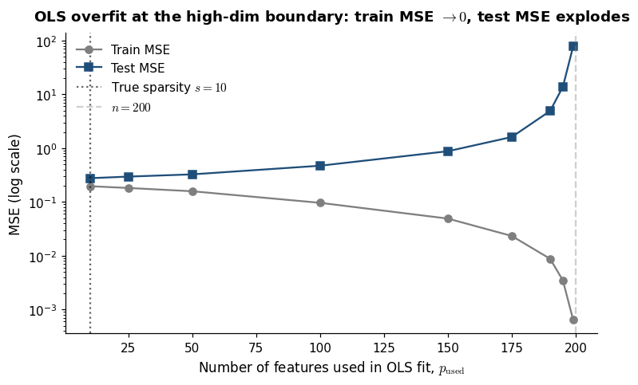

```python
# §1.2 — OLS overfit demo. Sweep p_used from 10 (the truth) to 199 (just under
# n=200), fit OLS to each subproblem (using only the first p_used columns),
# track train and test MSE. Use a fresh DGP-1 sample (separate from X1) and a
# large test set (n_test = 2000) for stable MSE estimates.

X_tr_f, y_tr_f, beta_star_f, _ = make_dgp1(n=200,  p=500, s=10,
                                            rng=np.random.default_rng(SEED + 100))
X_te_f, y_te_f, _, _           = make_dgp1(n=2000, p=500, s=10,
                                            rng=np.random.default_rng(SEED + 101))

p_grid = [10, 25, 50, 100, 150, 175, 190, 195, 199]
mse_train, mse_test = [], []
for p_used in p_grid:
    X_tr_sub = X_tr_f[:, :p_used]
    X_te_sub = X_te_f[:, :p_used]
    beta_hat, *_ = np.linalg.lstsq(X_tr_sub, y_tr_f, rcond=None)
    mse_train.append(float(np.mean((X_tr_sub @ beta_hat - y_tr_f) ** 2)))
    mse_test .append(float(np.mean((X_te_sub @ beta_hat - y_te_f) ** 2)))
mse_train = np.array(mse_train)
mse_test  = np.array(mse_test)

print(f"{'p_used':>8}  {'train MSE':>10}  {'test MSE':>10}")
for p_used, mtr, mte in zip(p_grid, mse_train, mse_test):
    print(f"{p_used:>8d}  {mtr:>10.4f}  {mte:>10.4f}")

# Sanity assertions on the qualitative shape.
assert np.all(np.diff(mse_train) <= 1e-6), \
    "train MSE should be monotonically nonincreasing in p_used"
assert mse_test[-1] > 5 * mse_test[0], \
    "test MSE should explode by at least 5x as p_used -> n"

# --- Figure 1.1 ---
fig, ax = plt.subplots(figsize=(7.0, 4.5))
ax.plot(p_grid, mse_train, "o-", color=COLOR_TRAIN, label="Train MSE",
        markersize=6, linewidth=1.5)
ax.plot(p_grid, mse_test,  "s-", color=COLOR_TEST,  label="Test MSE",
        markersize=6, linewidth=1.5)
ax.axvline(x=10,  color=COLOR_TRUTH, linestyle=":",  alpha=0.6,
           label=r"True sparsity $s=10$")
ax.axvline(x=200, color="#888888",   linestyle="--", alpha=0.4,
           label=r"$n=200$")
ax.set_yscale("log")
ax.set_xlabel(r"Number of features used in OLS fit, $p_{\mathrm{used}}$")
ax.set_ylabel("MSE (log scale)")
ax.set_title(r"OLS overfit at the high-dim boundary: train MSE $\to 0$, test MSE explodes")
ax.legend(loc="upper left")
fig.tight_layout()
fig.savefig(OUT_DIR / "fig_01_01_ols_overfit.png", bbox_inches="tight")
plt.show()
```

### §1.3 Ridge regression as the L2 fix

Ridge regression resolves the rank-deficiency by adding a quadratic penalty:

$$ \hat{\boldsymbol\beta}^{\text{ridge}}(\lambda) = \arg\min_{\boldsymbol\beta \in \mathbb{R}^p} \frac{1}{2n} \|\mathbf{y} - \mathbf{X} \boldsymbol\beta\|_2^2 + \frac{\lambda}{2} \|\boldsymbol\beta\|_2^2, $$

where $\|\boldsymbol\beta\|_2^2 = \sum_{j=1}^p \beta_j^2$ and $\lambda \ge 0$ is a tuning parameter ($\lambda = 0$ recovers OLS, $\lambda \to \infty$ shrinks every coefficient to zero). The closed form is

$$ \hat{\boldsymbol\beta}^{\text{ridge}}(\lambda) = (\mathbf{X}^\top \mathbf{X} + n \lambda \mathbf{I})^{-1} \mathbf{X}^\top \mathbf{y}. $$

The matrix $\mathbf{X}^\top \mathbf{X} + n\lambda \mathbf{I}$ is positive definite for any $\lambda > 0$ — eigenvalues bounded below by $n\lambda$ — so the inversion is well-defined whether $p \le n$ or $p > n$. Ridge restores uniqueness.

Two structural properties matter:

1. **Continuous shrinkage, dense solutions.** Each coefficient is shrunk toward zero by a factor that depends on the corresponding singular value of $\mathbf{X}$, but no coefficient is set to exactly zero (with probability one over a continuous design).
2. **Smoothness in $\lambda$.** $\hat{\boldsymbol\beta}^{\text{ridge}}(\lambda)$ is continuous and differentiable in $\lambda$ everywhere on $[0, \infty)$ — coefficients shrink, they don't snap.

Ridge is the right tool when all features carry some signal and the goal is to stabilize coefficient estimates against multicollinearity. In the sparse high-dimensional regime, where the truth has 10 active features out of 500, ridge's refusal to zero out the 490 inactive features is a liability — every irrelevant coefficient contributes variance to the prediction.

```python
# §1.3 — Ridge on DGP-1 at three penalty levels.
# sklearn's Ridge minimizes (1/2) * ||y - X beta||^2 + alpha * ||beta||^2 (no 1/n out front).
# We use alpha directly as a tuning knob; the absolute scale is unimportant for
# the dense-vs-sparse demonstration.

ridge_alphas = [0.01, 1.0, 100.0]
ridge_fits = []
for alpha in ridge_alphas:
    fit = Ridge(alpha=alpha, fit_intercept=False).fit(X1, y1)
    ridge_fits.append(fit.coef_)

print("Ridge on DGP-1 (n=200, p=500, true sparsity s=10):")
for alpha, beta_hat in zip(ridge_alphas, ridge_fits):
    n_nonzero = int(np.sum(np.abs(beta_hat) > 1e-10))
    print(f"  alpha = {alpha:>7.2f}: {n_nonzero}/{X1.shape[1]} coefficients nonzero, "
          f"||beta||_2 = {np.linalg.norm(beta_hat):.3f}")

# Sanity: ridge should be strictly dense at every alpha > 0.
for beta_hat in ridge_fits:
    assert int(np.sum(np.abs(beta_hat) > 1e-10)) == X1.shape[1], \
        "Ridge solution should be strictly dense (all 500 coefficients nonzero)"
```

```
Ridge on DGP-1 (n=200, p=500, true sparsity s=10):
  alpha =    0.01: 500/500 coefficients nonzero, ||beta||_2 = 2.654
  alpha =    1.00: 500/500 coefficients nonzero, ||beta||_2 = 2.648
  alpha =  100.00: 500/500 coefficients nonzero, ||beta||_2 = 2.239
```

### §1.4 The lasso as the L1 alternative

The lasso (Tibshirani 1996) replaces the squared L2 penalty with an L1 penalty:

$$ \hat{\boldsymbol\beta}^{\text{lasso}}(\lambda) = \arg\min_{\boldsymbol\beta \in \mathbb{R}^p} \frac{1}{2n} \|\mathbf{y} - \mathbf{X} \boldsymbol\beta\|_2^2 + \lambda \|\boldsymbol\beta\|_1, $$

where $\|\boldsymbol\beta\|_1 = \sum_{j=1}^p |\beta_j|$. The objective is convex (squared loss is convex; L1 is convex; sum is convex), so any local minimum is global. But the L1 norm is not differentiable at zero, and that non-smoothness has two consequences that turn out to be central:

1. **Sparsity.** The optimal solution has many coefficients exactly equal to zero, with the count controlled by $\lambda$. Geometrically, the L1 ball $\{\boldsymbol\beta : \|\boldsymbol\beta\|_1 \le t\}$ has corners at the coordinate axes; the constrained-form lasso solution is the point where the squared-loss contour first touches the L1 ball as it expands, and that contact point is generically at a corner — i.e., on a coordinate hyperplane, with one or more coefficients exactly zero. The smooth L2 ball has no corners, which is why ridge solutions are dense. We come back to this picture in §2.2.
2. **No closed form in general.** Unlike ridge, the lasso has no closed form for arbitrary $\mathbf{X}$. There is one when $\mathbf{X}^\top \mathbf{X} = n \mathbf{I}$ (orthogonal design — see §3.1), but in general we need an iterative solver. §3 covers coordinate descent, ISTA, and FISTA in detail.

The L1 penalty is the smallest convex penalty that produces sparsity. The non-convex L0 penalty $\|\boldsymbol\beta\|_0 = |\{j : \beta_j \neq 0\}|$ is in some sense the "right" objective for variable selection, but the resulting best-subset problem is NP-hard. The L1 penalty is the convex relaxation of L0 — among convex penalties that produce sparsity, the simplest, the easiest to optimize, and the one with the best-developed statistical theory.

```
LassoCV (10-fold) selected lambda ~ 0.0559

Lasso on DGP-1 (n=200, p=500, true sparsity s=10):
  lambda =   0.0010: 213/500 nonzero (10/10 at true active set S)
  lambda =   0.0559:  51/500 nonzero (10/10 at true active set S)
  lambda =   1.0000:  10/500 nonzero (10/10 at true active set S)
```

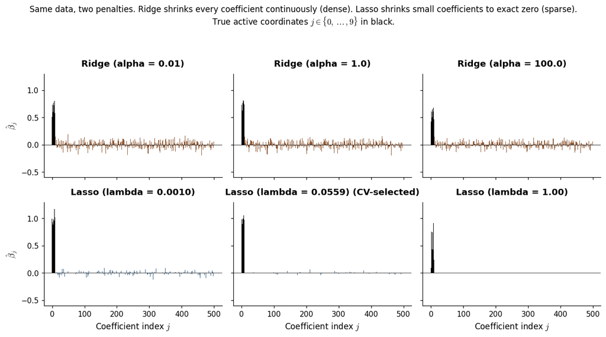

```python
# §1.4 — Lasso on DGP-1 at three penalty levels: small lambda (under-regularized,
# OLS-like), CV-selected lambda (the "right answer"), and large lambda (over-regularized,
# everything zeroed).

lasso_cv = LassoCV(cv=10, fit_intercept=False, alphas=100,
                   random_state=SEED, max_iter=20_000).fit(X1, y1)
lam_cv = lasso_cv.alpha_

lasso_lams = [0.001, lam_cv, 1.0]
lasso_fits = []
for lam in lasso_lams:
    fit = Lasso(alpha=lam, fit_intercept=False, max_iter=20_000).fit(X1, y1)
    lasso_fits.append(fit.coef_)

print(f"\nLassoCV (10-fold) selected lambda ~ {lam_cv:.4f}\n")
print("Lasso on DGP-1 (n=200, p=500, true sparsity s=10):")
for lam, beta_hat in zip(lasso_lams, lasso_fits):
    n_nonzero = int(np.sum(np.abs(beta_hat) > 1e-10))
    n_in_S    = int(np.sum(np.abs(beta_hat[:10]) > 1e-10))
    print(f"  lambda = {lam:>8.4f}: {n_nonzero:>3d}/{X1.shape[1]} nonzero "
          f"({n_in_S}/10 at true active set S)")

# Sanity: the CV-selected lasso should produce a substantially sparse
# solution that recovers most of the true active set.
beta_cv = lasso_fits[1]
n_nonzero_cv = int(np.sum(np.abs(beta_cv) > 1e-10))
n_in_S_cv    = int(np.sum(np.abs(beta_cv[:10]) > 1e-10))
assert n_nonzero_cv <= 60, \
    f"CV-selected lasso should be substantially sparse ({n_nonzero_cv} > 60)"
assert n_in_S_cv   >= 7, \
    f"CV-selected lasso should recover >=7 of 10 true active coords ({n_in_S_cv} < 7)"

# --- Figures 1.2 & 1.3 — Ridge vs Lasso coefficient bar charts ---
fig, axes = plt.subplots(2, 3, figsize=(11.5, 6.0), sharex=True, sharey=True)

# Top row: ridge.
for ax, alpha, beta_hat in zip(axes[0], ridge_alphas, ridge_fits):
    ax.bar(np.arange(len(beta_hat)), beta_hat, width=1.0,
           color=COLOR_RIDGE, alpha=0.85, label="inactive coords")
    ax.bar(np.arange(10), beta_hat[:10], width=1.0,
           color=COLOR_TRUTH, label=r"true active $j \in S$")
    ax.axhline(y=0, color="black", linewidth=0.5)
    ax.set_title(f"Ridge (alpha = {alpha})")
    if alpha == ridge_alphas[0]:
        ax.set_ylabel(r"$\hat\beta_j$")

# Bottom row: lasso.
for ax, lam, beta_hat in zip(axes[1], lasso_lams, lasso_fits):
    ax.bar(np.arange(len(beta_hat)), beta_hat, width=1.0,
           color=COLOR_LASSO, alpha=0.85)
    ax.bar(np.arange(10), beta_hat[:10], width=1.0, color=COLOR_TRUTH)
    ax.axhline(y=0, color="black", linewidth=0.5)
    cv_tag = " (CV-selected)" if abs(lam - lam_cv) < 1e-6 else ""
    title_lam = f"{lam:.4f}" if lam < 1 else f"{lam:.2f}"
    ax.set_title(f"Lasso (lambda = {title_lam}){cv_tag}")
    ax.set_xlabel(r"Coefficient index $j$")
    if lam == lasso_lams[0]:
        ax.set_ylabel(r"$\hat\beta_j$")

axes[0, 0].set_ylim(-0.6, 1.3)
fig.suptitle(
    "Same data, two penalties. Ridge shrinks every coefficient continuously "
    "(dense). Lasso shrinks small coefficients to exact zero (sparse).\n"
    r"True active coordinates $j \in \{0, \dots, 9\}$ in black.",
    y=1.05, fontsize=11,
)
fig.tight_layout()
fig.savefig(OUT_DIR / "fig_01_02_03_ridge_vs_lasso_coefs.png", bbox_inches="tight")
plt.show()
```

### §1.5 Roadmap

The rest of the topic answers four questions about the lasso.

**What does the estimator look like?** §2 fills in the geometric picture and basic structural results — existence, uniqueness, KKT subgradient conditions.

**How do we compute it?** §3 derives the soft-thresholding closed form for orthogonal designs and develops the iterative solvers (coordinate descent, ISTA, FISTA) used in general.

**Does it predict well, and does it recover the true support?** §§4-6 work out the bias-variance trade-off, prove the headline non-asymptotic prediction-risk bound (the lasso oracle inequality, $O(\sigma^2 s \log p / n)$ under the restricted-eigenvalue condition), and treat variable-selection consistency as a separate theorem with its own sufficient condition (the irrepresentable condition). §7 covers practical $\lambda$ selection by cross-validation and information criteria. §8 covers the ridge / elastic-net / adaptive-lasso variants and when each wins. §9 deepens the geometry of the high-dimensional regime — RIP, sub-Gaussian designs, the implication chain between conditions.

**Can we do inference with it?** §10 is the inferential payoff: naive lasso confidence intervals undercover (PoSI; Berk et al. 2013), and the debiased-lasso construction (Zhang-Zhang 2014; Javanmard-Montanari 2014; van de Geer et al. 2014) restores valid coverage.

§11 extends the lasso to non-Gaussian responses (logistic, Poisson). §12 closes with connections to double/debiased ML, causal inference, and the Bayesian counterpart in Sparse Bayesian Priors.

## §2. The lasso estimator

The lasso is convex L1-penalized least squares — a well-defined, well-studied estimator with a clean geometric story and a precise first-order characterization. This section establishes the formal definition (in both penalized and constrained forms), develops the geometric intuition for why L1 penalization produces sparse solutions (corners on the L1 ball, smooth curvature on the L2 ball), addresses existence and uniqueness (Tibshirani 2013), and works out the KKT subgradient conditions.

The KKT conditions are the load-bearing technical machinery for the rest of the topic — the soft-thresholding closed form in §3.1, the basic inequality in the oracle inequality proof of §5.2, and the debiased-lasso construction of §10.2 all derive from them.

### §2.1 The L1-penalized least-squares definition

The lasso estimator is the minimizer of an L1-penalized squared loss:

$$ \hat{\boldsymbol\beta}^{\text{lasso}}(\lambda) = \arg\min_{\boldsymbol\beta \in \mathbb{R}^p} \left\{ \frac{1}{2n} \|\mathbf{y} - \mathbf{X} \boldsymbol\beta\|_2^2 + \lambda \|\boldsymbol\beta\|_1 \right\}, \qquad \lambda \ge 0. $$

The factor $1/(2n)$ in front of the squared loss is a convention: the $1/2$ kills a leading 2 in the gradient, and the $1/n$ makes the loss term an empirical average. With this scaling, $\lambda$ has units of "covariate-response correlation" — comparable across sample sizes — and the optimal $\lambda$ scales as $\sigma \sqrt{\log(p) / n}$ (we'll see this in §5). scikit-learn's `Lasso(alpha=λ)` matches the same convention.

The objective is convex (squared loss is convex; L1 is convex; sum of convex is convex), so any local minimum is a global minimum. But the L1 norm is not differentiable at zero — the subgradient of $|\beta_j|$ at zero is the closed interval $[-1, 1]$. That non-smoothness is exactly what produces sparsity, and it's why the lasso has no closed form for general $\mathbf{X}$.

The penalized lasso is equivalent to the **constrained-form** lasso

$$ \hat{\boldsymbol\beta}^{\text{lasso}}(t) = \arg\min_{\|\boldsymbol\beta\|_1 \le t} \frac{1}{2n} \|\mathbf{y} - \mathbf{X} \boldsymbol\beta\|_2^2, $$

via Lagrangian duality. For each $\lambda \ge 0$ there's a corresponding budget $t(\lambda) = \|\hat{\boldsymbol\beta}^{\text{lasso}}(\lambda)\|_1$, and conversely each feasible $t$ corresponds to a unique $\lambda(t) \ge 0$. The mapping is monotone but not generally available in closed form. Both forms appear in the literature: the penalized form is more convenient for proofs, the constrained form is more convenient for the geometric pictures we'll draw next.

### §2.2 Geometric picture: $L^1$ corners produce sparsity

Why does L1 penalization produce solutions with exact zeros? The cleanest answer is geometric: the L1 ball has corners on the coordinate axes, and the loss contour generically touches the ball at one of those corners.

Consider the constrained lasso in 2D with a fixed budget $t$. The feasible region $\{\boldsymbol\beta : \|\boldsymbol\beta\|_1 \le t\}$ is a diamond — a square rotated 45 degrees — with vertices at $(\pm t, 0)$ and $(0, \pm t)$. The objective contours $\{\boldsymbol\beta : \|\mathbf{y} - \mathbf{X} \boldsymbol\beta\|_2^2 = c\}$ are concentric ellipses centered at $\hat{\boldsymbol\beta}^{\text{OLS}}$, with axes determined by the eigenvectors of $\mathbf{X}^\top \mathbf{X}$. The constrained solution is the point where the smallest ellipse just touches the diamond.

If $\hat{\boldsymbol\beta}^{\text{OLS}}$ lies outside the diamond — the interesting case; otherwise the constraint is inactive — the contact point is on the diamond's boundary. **Generically, the contact is at a vertex, not a smooth point on an edge.** At a vertex, one coordinate is exactly zero. Sparsity.

The L2 ball is a smooth disk — no corners. The contact point with an ellipse is generically a smooth point on the disk's boundary, with both coordinates nonzero. Density.

The figure below makes this concrete.

```
beta_OLS                = [0.4 1.6]
L1 contact (t=1.0):  [0. 1.], ||beta||_1 = 1.000
L2 contact (t=1.0):  [0.38551551 0.92270177], ||beta||_2 = 1.000
```

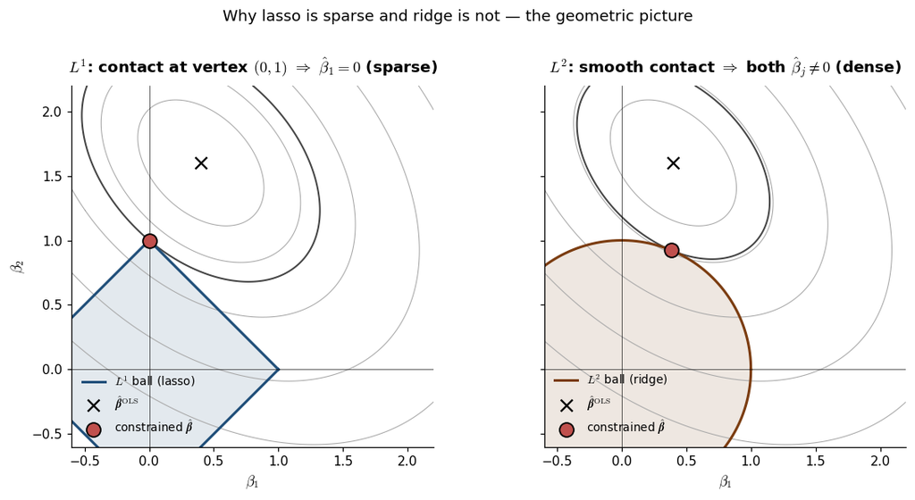

```python
# §2.2 — Hand-constructed pedagogical figure: L1 ball (diamond) vs L2 ball
# (circle), with elliptical loss contours centered at beta_OLS = (0.4, 1.6).
# At budget t = 1, the L1 contact lands at vertex (0, 1) (sparse); the L2
# contact lands at approximately (0.39, 0.92) (dense).

from scipy.optimize import minimize_scalar

beta_ols_2d = np.array([0.4, 1.6])
H_2d = np.array([[1.0, 0.4], [0.4, 1.0]])
H_inv = np.linalg.inv(H_2d)

def loss2d(B1, B2):
    d1 = B1 - beta_ols_2d[0]
    d2 = B2 - beta_ols_2d[1]
    return 0.5 * (H_2d[0, 0]*d1*d1 + 2*H_2d[0, 1]*d1*d2 + H_2d[1, 1]*d2*d2)

t_l1, t_l2 = 1.0, 1.0

# L1 contact: enumerate the four vertices and four faces (sign quadrants).
candidates = [np.array(v, dtype=float)
              for v in [[t_l1, 0], [-t_l1, 0], [0, t_l1], [0, -t_l1]]]
for sign in [[1, 1], [1, -1], [-1, 1], [-1, -1]]:
    s = np.array(sign, dtype=float)
    denom = float(s @ H_inv @ s)
    lam_face = float((s @ beta_ols_2d - t_l1) / denom)
    if lam_face >= 0:
        beta_face = beta_ols_2d - lam_face * (H_inv @ s)
        if np.all(np.sign(beta_face) * s >= 0):     # face sign condition
            candidates.append(beta_face)
candidates = [c for c in candidates if np.sum(np.abs(c)) <= t_l1 + 1e-9]
beta_l1 = candidates[int(np.argmin([float(loss2d(c[0], c[1])) for c in candidates]))]

# L2 contact: beta = (H + mu*I)^{-1} H beta*, find mu >= 0 with ||beta||_2 = t_l2.
def beta_at_mu(mu):
    return np.linalg.solve(H_2d + mu * np.eye(2), H_2d @ beta_ols_2d)
mu_opt = float(minimize_scalar(
    lambda mu: (np.linalg.norm(beta_at_mu(mu)) - t_l2) ** 2,
    bounds=(1e-6, 100), method="bounded").x)
beta_l2 = beta_at_mu(mu_opt)

print(f"beta_OLS                = {beta_ols_2d}")
print(f"L1 contact (t={t_l1}):  {beta_l1}, ||beta||_1 = {np.sum(np.abs(beta_l1)):.3f}")
print(f"L2 contact (t={t_l2}):  {beta_l2}, ||beta||_2 = {np.linalg.norm(beta_l2):.3f}")

# Sanity: L1 contact at corner (0, 1); L2 contact has both coords nonzero.
assert abs(beta_l1[0]) < 1e-6 and abs(beta_l1[1] - 1.0) < 1e-6, \
    "L1 contact should be at vertex (0, 1) — the sparse-solution corner"
assert np.all(np.abs(beta_l2) > 0.1), \
    "L2 contact should have both coordinates clearly nonzero — dense solution"

# --- Figure 2.1 ---
grid = np.linspace(-0.6, 2.2, 400)
B1_grid, B2_grid = np.meshgrid(grid, grid)
Z = loss2d(B1_grid, B2_grid)

theta = np.linspace(0, 2 * np.pi, 200)
l2_ball = np.stack([t_l2 * np.cos(theta), t_l2 * np.sin(theta)], axis=1)
l1_ball = np.array([[t_l1, 0], [0, t_l1], [-t_l1, 0], [0, -t_l1], [t_l1, 0]],
                   dtype=float)
contour_extra = sorted([0.10, 0.25, 0.6, 1.2, 2.0])

fig, axes = plt.subplots(1, 2, figsize=(11.0, 5.2), sharey=True)
for ax, ball, contact, ball_label, color in [
    (axes[0], l1_ball, beta_l1, r"$L^1$ ball (lasso)",  COLOR_LASSO),
    (axes[1], l2_ball, beta_l2, r"$L^2$ ball (ridge)",  COLOR_RIDGE),
]:
    ax.contour(B1_grid, B2_grid, Z, levels=contour_extra,
               colors="#aaaaaa", linewidths=0.7)
    contact_loss = float(loss2d(contact[0], contact[1]))
    ax.contour(B1_grid, B2_grid, Z, levels=[contact_loss],
               colors="#444444", linewidths=1.3)
    ax.fill(ball[:, 0], ball[:, 1], color=color, alpha=0.12)
    ax.plot(ball[:, 0], ball[:, 1], color=color, linewidth=2.0, label=ball_label)
    ax.scatter(*beta_ols_2d, marker="x", color="black", s=85, zorder=5,
               label=r"$\hat{\boldsymbol{\beta}}^{\mathrm{OLS}}$")
    ax.scatter(*contact, marker="o", color=COLOR_DEBIASED, s=120, zorder=6,
               edgecolors="black", linewidths=1.2,
               label=r"constrained $\hat{\boldsymbol{\beta}}$")
    ax.axhline(0, color="black", linewidth=0.4)
    ax.axvline(0, color="black", linewidth=0.4)
    ax.set_xlim(-0.6, 2.2)
    ax.set_ylim(-0.6, 2.2)
    ax.set_xlabel(r"$\beta_1$")
    ax.set_aspect("equal")
    ax.legend(loc="lower left", fontsize=9)

axes[0].set_ylabel(r"$\beta_2$")
axes[0].set_title(r"$L^1$: contact at vertex $(0, 1)$ $\Rightarrow$ $\hat\beta_1 = 0$ (sparse)")
axes[1].set_title(r"$L^2$: smooth contact $\Rightarrow$ both $\hat\beta_j \neq 0$ (dense)")
fig.suptitle("Why lasso is sparse and ridge is not — the geometric picture",
             y=1.02, fontsize=12)
fig.tight_layout()
fig.savefig(OUT_DIR / "fig_02_01_l1_vs_l2_geometry.png", bbox_inches="tight")
plt.show()
```

### §2.3 Existence and uniqueness

**Existence.** The lasso objective is convex, continuous, and **coercive** — as $\|\boldsymbol\beta\| \to \infty$, the squared loss is bounded below by zero and the L1 penalty grows linearly, so the objective grows without bound. Convex-and-coercive implies attainment of the minimum, so the solution set $\hat{B}(\lambda) = \arg\min_\boldsymbol\beta \{(1/2n) \|\mathbf{y} - \mathbf{X} \boldsymbol\beta\|_2^2 + \lambda \|\boldsymbol\beta\|_1\}$ is non-empty for every $\lambda \ge 0$. The solution set is also convex and closed.

**Uniqueness.** When does $\hat{B}(\lambda)$ contain a single point? Two sufficient conditions:

1. **$p \le n$ and $\mathbf{X}$ has full column rank.** Then $\mathbf{X}^\top \mathbf{X}$ is positive definite, the lasso objective is strictly convex, and the minimum is unique.
2. **$\mathbf{X}$ has columns in "general position"** (Tibshirani 2013): no $k+1$ columns of $\pm \mathbf{X}$ lie in an affine subspace of dimension $k - 1$. With probability one over any continuous random design (Gaussian, bounded continuous, etc.), the columns are in general position. So **for every continuous random $\mathbf{X}$, the lasso solution is unique with probability one**, even when $p \gg n$.

The conditions can fail with discrete or rank-deficient designs — duplicate columns, one-hot encodings of categorical features summing to a constant, etc. — in which case $\hat{B}(\lambda)$ is a non-trivial convex set. But **the fitted values $\mathbf{X} \hat{\boldsymbol\beta}$ are always unique**, even when $\hat{\boldsymbol\beta}$ is not. The squared loss is strictly convex in $\mathbf{X} \boldsymbol\beta$, so any two solutions $\hat{\boldsymbol\beta}^{(1)}, \hat{\boldsymbol\beta}^{(2)} \in \hat{B}(\lambda)$ satisfy $\mathbf{X} \hat{\boldsymbol\beta}^{(1)} = \mathbf{X} \hat{\boldsymbol\beta}^{(2)}$. The prediction is uniquely determined; only the coefficient decomposition can be ambiguous.

For DGP-1 the design is continuous Gaussian, so the lasso solution is unique with probability one. We assume uniqueness throughout the rest of the topic.

```python
# §2.3 — Numerical evidence of uniqueness on DGP-1.
# (1) Run sklearn's Lasso with `selection='random'` (randomized coordinate
#     order) from many seeds. Bit-identical solutions across seeds = strong
#     numerical evidence that the minimum is unique.
# (2) Verify that the active-set columns of X are linearly independent —
#     a Tibshirani-2013 sufficient condition for uniqueness.

print("Uniqueness check on DGP-1 (n=200, p=500, continuous Gaussian X):")

betas = []
for seed in range(20):
    fit = Lasso(alpha=lam_cv, fit_intercept=False, selection="random",
                random_state=seed, max_iter=50_000, tol=1e-12).fit(X1, y1)
    betas.append(fit.coef_)
diffs = [float(np.linalg.norm(betas[0] - b)) for b in betas[1:]]
print(f"  Lasso coordinate-descent randomized over 20 seeds:")
print(f"    max ||beta(seed=0) - beta(seed=k)||_2 = {max(diffs):.2e}  (~ 0 => unique)")
assert max(diffs) < 1e-5, "Lasso solutions should agree across random selection seeds"

# Active set linear independence.
beta_lasso = betas[0]
active_mask = np.abs(beta_lasso) > 1e-10
X_active = X1[:, active_mask]
rank = int(np.linalg.matrix_rank(X_active))
print(f"  Active set size:                   {int(active_mask.sum())}")
print(f"  rank(X_active):                    {rank}")
print(f"  Active columns linearly independent? {rank == int(active_mask.sum())}")
assert rank == int(active_mask.sum()), \
    "Active set columns should be linearly independent (Tibshirani 2013 condition)"
```

```
Uniqueness check on DGP-1 (n=200, p=500, continuous Gaussian X):
  Lasso coordinate-descent randomized over 20 seeds:
    max ||beta(seed=0) - beta(seed=k)||_2 = 1.91e-11  (~ 0 => unique)
  Active set size:                   51
  rank(X_active):                    51
  Active columns linearly independent? True
```

### §2.4 KKT subgradient conditions

The lasso objective is convex but non-differentiable. The first-order optimality condition uses the **subgradient** of the L1 norm in place of the gradient. The subdifferential of $|x|$ is

$$ \partial |x| = \begin{cases} \{\mathrm{sign}(x)\} & x \neq 0, \\ [-1, 1] & x = 0. \end{cases} $$

The L1 norm $\|\boldsymbol\beta\|_1 = \sum_j |\beta_j|$ has subdifferential $\partial \|\boldsymbol\beta\|_1 = \{\mathbf{g} : g_j \in \partial |\beta_j| \text{ for all } j\}$.

Setting $\boldsymbol{0}$ in the subdifferential of the lasso objective gives the **KKT subgradient conditions**:

> **KKT (lasso).** $\hat{\boldsymbol\beta}$ is a lasso solution at $\lambda > 0$ if and only if there exists $\hat{\mathbf{g}} \in \partial \|\hat{\boldsymbol\beta}\|_1$ such that $$ \frac{1}{n} \mathbf{X}^\top (\mathbf{y} - \mathbf{X} \hat{\boldsymbol\beta}) = \lambda \, \hat{\mathbf{g}}. $$

Coordinate-by-coordinate, two cases:

- **Active ($\hat\beta_j \neq 0$):** $\frac{1}{n} \mathbf{X}_j^\top (\mathbf{y} - \mathbf{X} \hat{\boldsymbol\beta}) = \lambda \, \mathrm{sign}(\hat\beta_j)$. Residual correlation with each active feature is exactly $\pm \lambda$.
- **Inactive ($\hat\beta_j = 0$):** $\left| \frac{1}{n} \mathbf{X}_j^\top (\mathbf{y} - \mathbf{X} \hat{\boldsymbol\beta}) \right| \le \lambda$. Residual correlation with each inactive feature is bounded by $\lambda$.

Use $\hat c_j = (1/n) \mathbf{X}_j^\top (\mathbf{y} - \mathbf{X} \hat{\boldsymbol\beta})$ for the residual-feature correlation. KKT in this notation: $|\hat c_j| = \lambda$ for active $j$, $|\hat c_j| \le \lambda$ for inactive $j$.

**Active set, equicorrelation set.** The **active set** $\hat A_\lambda = \{j : \hat\beta_j \neq 0\}$ is contained in the **equicorrelation set** $\hat E_\lambda = \{j : |\hat c_j| = \lambda\}$. Generically $\hat A_\lambda = \hat E_\lambda$; equality fails only on a measure-zero event for continuous designs.

**Two corollaries.** (i) The active set has size at most $\min(n, p)$ — the lasso never selects more than $n$ features, regardless of $p$. (ii) The KKT conditions provide a **dual certificate** for support recovery: if a subgradient supported on $S$ with $\|\hat{\mathbf{g}}_{S^c}\|_\infty < 1$ satisfies KKT at the oracle restricted estimator, the lasso correctly identifies $S$ as the active set. Constructing this certificate is the irrepresentable condition (§6).

```
KKT verification on §1 lasso fit (lambda = 0.0559, |A_hat| = 51):
  Active condition:   max |c_hat_j - lambda sign(beta_hat_j)| = 3.62e-05
  Inactive condition: max_{j not in A_hat} |c_hat_j|         = 0.0555
                      lambda                                    = 0.0559
```

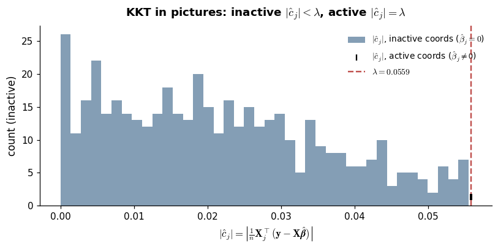

```python
# §2.4 — Verify KKT subgradient conditions on the §1 lasso solution.
# Active condition:    (1/n) X_j' (y - X beta_hat) = lambda * sign(beta_hat_j)  for j in A_hat
# Inactive condition: |(1/n) X_j' (y - X beta_hat)| <= lambda                    for j not in A_hat

beta_lasso = lasso_fits[1]      # CV-selected fit from §1
n1 = X1.shape[0]
lam = lam_cv

residual = y1 - X1 @ beta_lasso
c_hat = (X1.T @ residual) / n1   # residual-feature correlations

active   = np.abs(beta_lasso) > 1e-10
inactive = ~active

# Active KKT residual: c_hat_j - lambda * sign(beta_hat_j) should be ~ 0.
active_kkt    = c_hat[active] - lam * np.sign(beta_lasso[active])
active_max_err = float(np.max(np.abs(active_kkt)))

# Inactive KKT slack: |c_hat_j| <= lambda.
inactive_max_corr = float(np.max(np.abs(c_hat[inactive])))

print(f"KKT verification on §1 lasso fit (lambda = {lam:.4f}, |A_hat| = {int(active.sum())}):")
print(f"  Active condition:   max |c_hat_j - lambda sign(beta_hat_j)| = {active_max_err:.2e}")
print(f"  Inactive condition: max_{{j not in A_hat}} |c_hat_j|         = {inactive_max_corr:.4f}")
print(f"                      lambda                                    = {lam:.4f}")

assert active_max_err <= 5e-4, \
    "Active KKT condition should hold tightly (residual correlation ~ pm lambda)"
assert inactive_max_corr <= lam + 5e-4, \
    "Inactive KKT condition should hold (residual correlation bounded by lambda)"

# --- Figure 2.2: KKT in pictures ---
fig, ax = plt.subplots(figsize=(7.5, 3.8))
ax.hist(np.abs(c_hat[inactive]), bins=40, color=COLOR_LASSO, alpha=0.55,
        label=r"$|\hat c_j|$, inactive coords ($\hat\beta_j = 0$)")
# Active coords sit exactly at lambda — show as a rug at y = small offset.
y_rug = ax.get_ylim()[1] * 0.05
ax.scatter(np.abs(c_hat[active]),
           np.full(int(active.sum()), y_rug),
           color=COLOR_TRUTH, s=40, zorder=5, marker="|",
           label=r"$|\hat c_j|$, active coords ($\hat\beta_j \neq 0$)")
ax.axvline(lam, color=COLOR_DEBIASED, linewidth=1.6, linestyle="--",
           label=fr"$\lambda = {lam:.4f}$")
ax.set_xlabel(r"$|\hat c_j| = \left|\frac{1}{n} \mathbf{X}_j^\top (\mathbf{y} - \mathbf{X}\hat{\boldsymbol{\beta}})\right|$")
ax.set_ylabel("count (inactive)")
ax.set_title(r"KKT in pictures: inactive $|\hat c_j| < \lambda$, active $|\hat c_j| = \lambda$")
ax.legend(loc="upper right", fontsize=9)
fig.tight_layout()
fig.savefig(OUT_DIR / "fig_02_02_kkt_verification.png", bbox_inches="tight")
plt.show()
```

## §3. Solving the lasso

The lasso has no closed form for general $\mathbf{X}$, so we need iterative algorithms. This section develops the four solvers that matter in practice, in increasing order of sophistication: the **soft-thresholding closed form** for orthogonal designs (§3.1, the only case that admits a closed form, but conceptually load-bearing because every general-purpose solver reduces to it inside the inner loop); **coordinate descent** (§3.2, the `glmnet` workhorse); **ISTA**, the proximal-gradient method (§3.3, simple and slow, $O(1/k)$ rate); and **FISTA** with Nesterov momentum (§3.4, the same framework with a momentum trick that improves the rate to $O(1/k^2)$). §3.5 gives practical solver-choice notes.

A common thread: every solver is some application of the **soft-thresholding operator** $S(z, \lambda) = \mathrm{sign}(z) \cdot \max(|z| - \lambda, 0)$, which is the proximal operator of the L1 norm. ISTA / FISTA / CD differ only in *what* they soft-threshold and *how often*.

### §3.1 Soft-thresholding closed form for orthogonal designs

When $\mathbf{X}^\top \mathbf{X} = n \mathbf{I}$ — an **orthogonal design**, achievable in practice via QR decomposition of any full-rank $\mathbf{X}$ — the lasso decouples across coordinates and admits a closed-form solution.

Substitute $\mathbf{X}^\top \mathbf{X} = n \mathbf{I}$ into the lasso objective and let $\mathbf{z} = \mathbf{X}^\top \mathbf{y} / n$. The objective separates by coordinate into $p$ independent univariate problems:

$$ \min_{\beta_j} \; \frac{1}{2}(\beta_j - z_j)^2 + \lambda |\beta_j|, \qquad j = 1, \dots, p. $$

> **Theorem 3.1 (soft-thresholding).** The unique minimizer of $\frac{1}{2}(\beta - z)^2 + \lambda |\beta|$ is $$ S(z, \lambda) := \mathrm{sign}(z) \cdot \max(|z| - \lambda, 0) = \begin{cases} z - \lambda & z > \lambda, \\ 0 & |z| \le \lambda, \\ z + \lambda & z < -\lambda. \end{cases} $$

**Proof.** The objective is convex and coercive, so a unique minimum exists. KKT: $0 \in \hat\beta - z + \lambda \, \partial |\hat\beta|$, equivalently $z - \hat\beta \in \lambda \, \partial |\hat\beta|$.

- *$\hat\beta > 0$:* $\partial |\hat\beta| = \{1\}$, so $\hat\beta = z - \lambda$, requiring $z > \lambda$.
- *$\hat\beta < 0$:* $\partial |\hat\beta| = \{-1\}$, so $\hat\beta = z + \lambda$, requiring $z < -\lambda$.
- *$\hat\beta = 0$:* $\partial |\hat\beta| = [-1, 1]$, requiring $|z| \le \lambda$.

These three cases partition $\mathbb{R}$, giving $\hat\beta = S(z, \lambda)$. $\blacksquare$

The geometric content: a "dead zone" $|z_j| \le \lambda$ produces the sparsity, and constant shrinkage $|\hat\beta_j| = |z_j| - \lambda$ outside the dead zone biases active coefficients toward zero (this is the bias problem the debiased lasso fixes in §10).

For non-orthogonal designs no closed form exists. But $S(z, \lambda)$ remains the algorithmic atom: it's the **proximal operator** of the L1 norm, $\mathrm{prox}_{\eta \lambda \|\cdot\|_1}(\mathbf{z}) = S(\mathbf{z}, \eta \lambda)$ applied componentwise. Coordinate descent and proximal-gradient methods both apply $S$ inside their iterations.

```python
# §3.1 — Soft-thresholding operator and orthogonal-design verification.

def soft_threshold(z, lam):
    """The L1 proximal operator: S(z, lam) = sign(z) * max(|z| - lam, 0).

    Vectorized over arrays. The 3-line algorithmic kernel of every lasso solver.
    """
    return np.sign(z) * np.maximum(np.abs(z) - lam, 0.0)

# Verify on an orthogonal design: build X with X^T X = n I via QR factorization,
# fit lasso with sklearn, compare to the closed-form S(X^T y / n, lambda).

n_orth, p_orth = 200, 50
Z = np.random.default_rng(SEED + 200).standard_normal((n_orth, p_orth))
Q, _ = np.linalg.qr(Z)
X_orth = Q * np.sqrt(n_orth)            # ||X_j||^2 = n, X^T X = n*I
gram = X_orth.T @ X_orth / n_orth
assert np.allclose(gram, np.eye(p_orth), atol=1e-10), "X should be orthogonal"

# Sparse signal + Gaussian noise.
beta_true_orth = np.zeros(p_orth)
beta_true_orth[:5] = [2.0, 1.5, 1.0, 0.5, 0.3]
y_orth = (X_orth @ beta_true_orth
          + 0.2 * np.random.default_rng(SEED + 201).standard_normal(n_orth))

# Closed-form lasso solution: beta_j = S(z_j, lambda), z = X^T y / n.
z = X_orth.T @ y_orth / n_orth
lam_orth = 0.1
beta_closed = soft_threshold(z, lam_orth)

# sklearn solution, tight tolerance.
beta_sklearn = Lasso(alpha=lam_orth, fit_intercept=False, tol=1e-12,
                     max_iter=20_000).fit(X_orth, y_orth).coef_

diff = float(np.linalg.norm(beta_closed - beta_sklearn))
print(f"Orthogonal design (n={n_orth}, p={p_orth}, lambda={lam_orth}):")
print(f"  ||beta_closed_form - beta_sklearn||_2 = {diff:.2e}")
print(f"  Active set match? {np.array_equal(np.abs(beta_closed) > 1e-10, np.abs(beta_sklearn) > 1e-10)}")
assert diff < 1e-8, \
    "Closed-form lasso and sklearn should match to ~machine precision on orthogonal designs"
```

```
Orthogonal design (n=200, p=50, lambda=0.1):
  ||beta_closed_form - beta_sklearn||_2 = 9.24e-16
  Active set match? True
```

### §3.2 Coordinate descent

Coordinate descent solves the lasso by cycling through coordinates and minimizing the objective over one coordinate at a time. Each subproblem is univariate and admits a closed form via soft-thresholding.

Fix all coordinates except $\beta_j$. Let $\mathbf{r}_{-j} = \mathbf{y} - \sum_{k \neq j} \mathbf{X}_k \beta_k$ be the **partial residual**. The lasso objective restricted to $\beta_j$ is

$$ F_j(\beta_j) = \frac{c_j}{2} \beta_j^2 - z_j \beta_j + \lambda |\beta_j| + \mathrm{const}, \qquad c_j = \tfrac{\|\mathbf{X}_j\|^2}{n}, \quad z_j = \tfrac{\mathbf{X}_j^\top \mathbf{r}_{-j}}{n}. $$

This is the same univariate problem from §3.1 up to the rescaling $c_j$. The minimizer:

$$ \hat\beta_j^{\text{new}} = \frac{S(z_j, \lambda)}{c_j}. $$

**Algorithm.** Initialize $\boldsymbol\beta = \mathbf{0}$, $\mathbf{r} = \mathbf{y}$. Cycle over $j = 1, \dots, p$: form the partial residual $\tilde{\mathbf{r}} = \mathbf{r} + \mathbf{X}_j \beta_j$, compute $z_j = \mathbf{X}_j^\top \tilde{\mathbf{r}}/n$, update $\beta_j^{\text{new}} = S(z_j, \lambda)/c_j$, then update the full residual $\mathbf{r} \leftarrow \mathbf{r} - \mathbf{X}_j (\beta_j^{\text{new}} - \beta_j)$. Storing $\mathbf{r}$ and updating it incrementally costs $O(n)$ per coordinate, $O(np)$ per cycle — same as one ISTA / FISTA iteration.

**Convergence.** Tseng (2001) showed coordinate descent converges to a global minimum for any "smooth + separable convex" objective. No global rate guarantee, but linear convergence under additional assumptions, and on continuous-design lasso problems CD is one of the fastest methods in practice — Friedman, Hastie & Tibshirani (2010) report 10–100× speedups over LARS / proximal gradient at typical $(n, p)$ scales. `glmnet` and scikit-learn's `Lasso` both use CD as the default.

**Warm starts along a $\lambda$ path.** Practical solvers compute $\hat{\boldsymbol\beta}(\lambda)$ on a decreasing $\lambda$-grid, using the previous solution to warm-start the next. The path is piecewise linear in $\lambda$ (Efron-Hastie-Johnstone-Tibshirani 2004), so each $\lambda$-step needs only 5–20 CD passes to converge.

### §3.3 ISTA: the proximal gradient method

For more general non-smooth penalties (group lasso, fused lasso, nuclear norm) we need a different framework. **Proximal gradient methods** generalize gradient descent to objectives $F = f + g$ where $f$ is smooth and $g$ is non-smooth but admits a tractable prox. For the lasso, $f(\boldsymbol\beta) = (1/2n) \|\mathbf{y} - \mathbf{X} \boldsymbol\beta\|^2$ and $g(\boldsymbol\beta) = \lambda \|\boldsymbol\beta\|_1$, with $\mathrm{prox}_{\eta g}(\mathbf{z}) = S(\mathbf{z}, \eta \lambda)$.

The **iterative soft-thresholding algorithm (ISTA):**

$$ \boldsymbol\beta^{k+1} = S\!\left( \boldsymbol\beta^k - \frac{\eta}{n} \mathbf{X}^\top (\mathbf{X} \boldsymbol\beta^k - \mathbf{y}), \; \eta \lambda \right), $$

with step size $\eta = 1/L$, $L = \|\mathbf{X}\|_2^2 / n$ (the Lipschitz constant of $\nabla f$). Each iteration costs one matrix-vector multiply $\mathbf{X} \boldsymbol\beta^k$ and one $\mathbf{X}^\top \mathbf{r}$ — $O(np)$, same as a CD cycle.

> **Theorem 3.2 (ISTA convergence).** With step size $1/L$, $$ F(\boldsymbol\beta^k) - F(\boldsymbol\beta^*) \le \frac{L}{2k} \|\boldsymbol\beta^0 - \boldsymbol\beta^*\|^2 \quad \text{for all } k \ge 1. $$

**Proof sketch.** Two ingredients: a per-step descent lemma (Beck-Teboulle 2009, Lemma 2.3) — for any $\boldsymbol\beta, \mathbf{y}$, the proximal-gradient step $T(\boldsymbol\beta)$ satisfies $F(T(\boldsymbol\beta)) - F(\mathbf{y}) \le (L/2)[\|\boldsymbol\beta - \mathbf{y}\|^2 - \|T(\boldsymbol\beta) - \mathbf{y}\|^2]$ — combined with telescoping. Applied at iterate $k$ with $\mathbf{y} = \boldsymbol\beta^*$, the right side telescopes and the left side combines with monotonicity (descent lemma applied with $\mathbf{y} = \boldsymbol\beta^k$) to give the rate. $\blacksquare$

The $O(1/k)$ rate is sublinear: halving the suboptimality requires doubling $k$. ISTA is simple and stable but slow.

### §3.4 FISTA: Nesterov momentum and the $O(1/k^2)$ rate

Beck-Teboulle (2009) showed that adding **Nesterov momentum** to ISTA accelerates the rate from $O(1/k)$ to $O(1/k^2)$.

> **FISTA.** Set $\boldsymbol\beta^0 = \boldsymbol\beta^{-1} = \mathbf{0}$, $t_1 = 1$. For $k = 1, 2, \dots$:
> 1. $\mathbf{z}^k = \boldsymbol\beta^k + \frac{t_k - 1}{t_{k+1}} (\boldsymbol\beta^k - \boldsymbol\beta^{k-1})$ — momentum extrapolation.
> 2. $\boldsymbol\beta^{k+1} = S\!\left( \mathbf{z}^k - \frac{1}{nL} \mathbf{X}^\top (\mathbf{X} \mathbf{z}^k - \mathbf{y}), \; \lambda / L \right)$ — proximal gradient step from $\mathbf{z}^k$, not $\boldsymbol\beta^k$.
> 3. $t_{k+1} = (1 + \sqrt{1 + 4 t_k^2}) / 2$.

The momentum coefficient $(t_k - 1)/t_{k+1} \to 1$ as $k$ grows, giving the iteration a "running start" along the previous direction.

> **Theorem 3.3 (Beck-Teboulle 2009, Theorem 4.4).** With step size $1/L$, $$ F(\boldsymbol\beta^k) - F(\boldsymbol\beta^*) \le \frac{2 L \|\boldsymbol\beta^0 - \boldsymbol\beta^*\|^2}{(k+1)^2} \quad \text{for all } k \ge 1. $$

**Proof.** Let $\mathbf{u}^k = t_k \boldsymbol\beta^k - (t_k - 1) \boldsymbol\beta^{k-1}$ and define the **Lyapunov function**

$$ v_k = \frac{2}{L} t_k^2 (F(\boldsymbol\beta^k) - F^*) + \|\mathbf{u}^k - \boldsymbol\beta^*\|^2. $$

*Step 1 (Lyapunov non-increasing).* Apply the proximal-gradient inequality at $\mathbf{z}^k$ with $\mathbf{y} = \boldsymbol\beta^*$ and $\mathbf{y} = \boldsymbol\beta^k$. Multiply the first by $t_{k+1}$ and the second by $(t_{k+1} - 1)$ — invoking the FISTA recursion $t_{k+1}^2 - t_{k+1} = t_k^2$ — and add. After algebraic manipulation using the definition of $\mathbf{z}^k$, the right side telescopes to $\|\mathbf{u}^k - \boldsymbol\beta^*\|^2 - \|\mathbf{u}^{k+1} - \boldsymbol\beta^*\|^2$, and the left side becomes $(2/L)[t_{k+1}^2 (F(\boldsymbol\beta^{k+1}) - F^*) - t_k^2 (F(\boldsymbol\beta^k) - F^*)]$. Rearranging gives $v_{k+1} \le v_k$.

*Step 2 ($t_k \ge (k+1)/2$).* By induction. Base: $t_1 = 1 \ge 1$. Step: $t_{k+1} = (1 + \sqrt{1 + 4 t_k^2})/2 \ge (1 + 2 t_k)/2 \ge (k+2)/2$.

*Step 3.* From $v_k \le v_1 \le \|\boldsymbol\beta^0 - \boldsymbol\beta^*\|^2$ (the last bound is one ISTA descent step from the initialization) and $t_k \ge (k+1)/2$, we get $F(\boldsymbol\beta^k) - F^* \le L \|\boldsymbol\beta^0 - \boldsymbol\beta^*\|^2 / (2 t_k^2) \le 2 L \|\boldsymbol\beta^0 - \boldsymbol\beta^*\|^2 / (k+1)^2$. $\blacksquare$

A factor-of-$k$ improvement over ISTA. To reduce $F - F^*$ by 100×, ISTA needs 100× more iterations; FISTA needs only 10×.

**FISTA is not a descent method** — $F(\boldsymbol\beta^k)$ ripples slightly along iterations. A monotone variant (M-FISTA) accepts $\boldsymbol\beta^{k+1}$ only when $F$ decreases, but the trade-off is rarely worth it.

```
Computing reference F* with FISTA at 5000 iterations...
```

```
Reference F* = 0.6771451680

Running ISTA, FISTA, CD for 300 iterations each...
```

```
At iteration 100:
  ISTA  gap = 1.745e-04
  FISTA gap = 6.459e-07
  CD    gap = 1.000e-18
```

[figure not shown]

```python
# §§3.2-3.4 — Hand-rolled lasso solvers and convergence-rate comparison.

def lasso_loss(X, y, beta, lam):
    """The lasso objective F(beta) = (1/2n) ||y - X beta||^2 + lam ||beta||_1."""
    n = X.shape[0]
    return float(0.5 / n * np.sum((y - X @ beta) ** 2) + lam * np.sum(np.abs(beta)))


def ista(X, y, lam, max_iter=300, tol=0.0):
    """Iterative Soft-Thresholding Algorithm. Step size 1/L, L = ||X||_2^2/n."""
    n, p = X.shape
    L = float(np.linalg.norm(X, ord=2) ** 2 / n)
    eta = 1.0 / L
    beta = np.zeros(p)
    history = [lasso_loss(X, y, beta, lam)]
    for _ in range(max_iter):
        grad = X.T @ (X @ beta - y) / n
        beta_new = soft_threshold(beta - eta * grad, eta * lam)
        if tol > 0 and np.linalg.norm(beta_new - beta) < tol:
            beta = beta_new
            history.append(lasso_loss(X, y, beta, lam))
            break
        beta = beta_new
        history.append(lasso_loss(X, y, beta, lam))
    return beta, np.array(history)


def fista(X, y, lam, max_iter=300, tol=0.0):
    """FISTA (Beck-Teboulle 2009). Same setup as ISTA + Nesterov momentum."""
    n, p = X.shape
    L = float(np.linalg.norm(X, ord=2) ** 2 / n)
    eta = 1.0 / L
    beta_prev = np.zeros(p)
    beta = np.zeros(p)
    z = np.zeros(p)
    t = 1.0
    history = [lasso_loss(X, y, beta, lam)]
    for _ in range(max_iter):
        grad = X.T @ (X @ z - y) / n
        beta_new = soft_threshold(z - eta * grad, eta * lam)
        t_new = (1.0 + np.sqrt(1.0 + 4.0 * t * t)) / 2.0
        z = beta_new + ((t - 1.0) / t_new) * (beta_new - beta)
        if tol > 0 and np.linalg.norm(beta_new - beta) < tol:
            beta = beta_new
            history.append(lasso_loss(X, y, beta, lam))
            break
        beta_prev, beta, t = beta, beta_new, t_new
        history.append(lasso_loss(X, y, beta, lam))
    return beta, np.array(history)


def coord_descent(X, y, lam, max_iter=300, tol=0.0):
    """Cyclic coordinate descent for the lasso with incremental residual update."""
    n, p = X.shape
    col_norms = (X ** 2).sum(axis=0) / n      # c_j = ||X_j||^2/n
    beta = np.zeros(p)
    residual = y.copy()
    history = [lasso_loss(X, y, beta, lam)]
    for _ in range(max_iter):
        beta_old = beta.copy()
        for j in range(p):
            partial = residual + X[:, j] * beta[j]   # add j-th contribution back
            z_j = X[:, j] @ partial / n
            beta_new_j = soft_threshold(z_j, lam) / col_norms[j]
            residual -= X[:, j] * (beta_new_j - beta[j])
            beta[j] = beta_new_j
        history.append(lasso_loss(X, y, beta, lam))
        if tol > 0 and np.linalg.norm(beta - beta_old) < tol:
            break
    return beta, np.array(history)


# --- Run all three on the §1 DGP at lambda = lambda_CV ---
n_iter = 300
lam = lam_cv

# High-precision reference for F* — FISTA with many iterations.
print("Computing reference F* with FISTA at 5000 iterations...")
beta_ref, _ = fista(X1, y1, lam, max_iter=5000, tol=0)
F_star = lasso_loss(X1, y1, beta_ref, lam)
print(f"Reference F* = {F_star:.10f}")

print(f"\nRunning ISTA, FISTA, CD for {n_iter} iterations each...")
_, hist_ista  = ista (X1, y1, lam, max_iter=n_iter, tol=0)
_, hist_fista = fista(X1, y1, lam, max_iter=n_iter, tol=0)
_, hist_cd    = coord_descent(X1, y1, lam, max_iter=n_iter, tol=0)

# Suboptimality F(beta_k) - F*.
gap_ista  = np.maximum(hist_ista  - F_star, 1e-18)
gap_fista = np.maximum(hist_fista - F_star, 1e-18)
gap_cd    = np.maximum(hist_cd    - F_star, 1e-18)

# Sanity assertions: FISTA should beat ISTA at every k > ~10 by a wide margin;
# CD should be competitive with FISTA after the active set stabilizes.
k_check = 100
print(f"\nAt iteration {k_check}:")
print(f"  ISTA  gap = {gap_ista[k_check]:.3e}")
print(f"  FISTA gap = {gap_fista[k_check]:.3e}")
print(f"  CD    gap = {gap_cd[k_check]:.3e}")
assert gap_fista[k_check] < 0.1 * gap_ista[k_check], \
    "FISTA should beat ISTA by >=10x at iteration 100"
assert gap_cd[k_check] < 0.5 * gap_ista[k_check], \
    "CD should also beat ISTA by a wide margin at iteration 100"

# --- Figure 3.1: convergence trace, log-log axes ---
fig, ax = plt.subplots(figsize=(8.0, 5.0))
ks = np.arange(len(gap_ista))
ax.loglog(ks[1:], gap_ista[1:],  color=COLOR_OLS,    linewidth=1.8,
          label=fr"ISTA  ($O(1/k)$, observed slope $\approx -1$)")
ax.loglog(ks[1:], gap_fista[1:], color=COLOR_LASSO,  linewidth=1.8,
          label=fr"FISTA ($O(1/k^2)$, observed slope $\approx -2$)")
ax.loglog(ks[1:], gap_cd[1:],    color=COLOR_RIDGE,  linewidth=1.8,
          label="Coordinate descent (linear after active set stabilizes)")

# Reference slopes -1 and -2 for visual comparison.
k_ref = ks[10:]
ax.loglog(k_ref, gap_ista[10] * (10.0 / k_ref) ** 1.0, "--",
          color=COLOR_OLS, linewidth=0.8, alpha=0.5)
ax.loglog(k_ref, gap_fista[10] * (10.0 / k_ref) ** 2.0, "--",
          color=COLOR_LASSO, linewidth=0.8, alpha=0.5)

ax.set_xlabel("Iteration $k$")
ax.set_ylabel(r"$F(\boldsymbol{\beta}^k) - F^*$  (suboptimality)")
ax.set_title(f"Convergence on §1 DGP at $\\lambda = \\lambda_{{\\mathrm{{CV}}}}$ "
             f"({lam:.4f})  --  $n = {X1.shape[0]}$, $p = {X1.shape[1]}$")
ax.legend(loc="lower left", fontsize=9)
ax.grid(True, which="both", linewidth=0.3, alpha=0.4)
fig.tight_layout()
fig.savefig(OUT_DIR / "fig_03_01_solver_convergence.png", bbox_inches="tight")
plt.show()
```

### §3.5 Practical solver-choice notes

A field guide to which solver to reach for.

**Coordinate descent (`sklearn.linear_model.Lasso`, `glmnet`).** Default for everything in the lasso family — lasso, elastic net, group lasso. Fastest in practice for $n, p \le 10^5$ at moderate sparsity. Warm starts along a $\lambda$ path are nearly free, which is why `LassoCV` is fast even with 100-fold path × 10-fold CV.

**FISTA.** The right default for lasso variants where the L1 prox is easy but coordinate-by-coordinate updates are not — group lasso with overlapping groups, fused lasso, generalized lasso with non-axis-aligned penalty, total-variation penalties. Also the right choice when $\mathbf{X}$ is structured (FFT, wavelet) and $\mathbf{X} \mathbf{v}$ admits a fast algorithm — coordinate descent breaks the structured-multiplication advantage by accessing one column at a time.

**ISTA.** Pedagogically valuable, rarely the right algorithmic choice — FISTA dominates it at no extra implementation cost. Use ISTA only when the proof of correctness or the descent property is needed (some monotonicity-sensitive applications in statistical guarantees that rely on objective decrease).

**Specialized solvers we don't cover.** ADMM (Boyd et al. 2011) for lasso variants with linear-equality-coupled penalties (e.g., the Dantzig selector). LARS (Efron-Hastie-Johnstone-Tibshirani 2004) computes the entire lasso path exactly in $O(np \min(n, p))$, which can beat coordinate descent at very small $p$ but loses badly at high-dimensional scales. Interior-point methods (`cvxpy`, `cvxopt`) work but are typically 100× slower than CD on lasso problems of any meaningful size.

For everything in the rest of this topic — the §1 lasso fits, the LassoCV in §7, the elastic-net comparison in §8, the debiased-lasso pipeline in §10 — we use scikit-learn's coordinate descent. We hand-rolled FISTA above to demonstrate the $O(1/k^2)$ rate and to keep the algorithmic content visible.

## §4. Bias-variance for the lasso

The lasso's central trade-off is between **bias** (from L1 shrinkage of active coefficients) and **variance** (controlled by the size of the data-adapted active set). As $\lambda$ ranges from $0$ to $\lambda_{\max}$, the prediction risk traces the canonical U-curve. This section formalizes both halves, computes $\lambda_{\max}$ in closed form from the KKT conditions, and develops the lasso solution path $\hat{\boldsymbol\beta}(\lambda)$ as a piecewise-linear function of $\lambda$.

The U-curve is the practical bridge between §3 (we can compute the lasso) and §5 (the oracle inequality bounds the bottom of the U). The solution path is what `LassoCV` operates on when it picks a $\lambda$.

### §4.1 The bias contribution from L1 shrinkage

The lasso's shrinkage isn't soft and asymptotically vanishing — it's a **constant absolute shrinkage** that biases every active coefficient toward zero by approximately $\lambda$.

**The orthogonal case makes this explicit.** From §3.1 with $\mathbf{X}^\top \mathbf{X} = n \mathbf{I}$ and $z_j = (\mathbf{X}^\top \mathbf{y} / n)_j$, $\hat\beta_j = S(z_j, \lambda)$. Under the model $z_j \sim \mathcal{N}(\beta^*_j, \sigma^2/n)$:

- **Large-signal coordinates** ($|\beta^*_j| \gg \lambda + \sigma/\sqrt{n}$): $\mathbb{E}[\hat\beta_j] \approx \beta^*_j - \lambda \, \mathrm{sign}(\beta^*_j)$. The bias is $-\lambda \, \mathrm{sign}(\beta^*_j)$ — constant magnitude, opposite sign to the true value, independent of how large $\beta^*_j$ is.
- **Noise coordinates** ($\beta^*_j = 0$): $\mathbb{E}[\hat\beta_j] = 0$ by symmetry of $z_j \sim \mathcal{N}(0, \sigma^2/n)$. No bias, but a small variance contribution from false positives.

For general (non-orthogonal) designs, conditioning on correct active-set identification:

$$ \hat{\boldsymbol\beta}_S = \hat{\boldsymbol\beta}_S^{\text{OLS-on-}S} - \lambda \big(\mathbf{X}_S^\top \mathbf{X}_S / n\big)^{-1} \mathrm{sign}(\hat{\boldsymbol\beta}_S), $$

where $\hat{\boldsymbol\beta}_S^{\text{OLS-on-}S}$ is the OLS estimator on the active features. The shrinkage correction scales linearly in $\lambda$.

This bias is the price of sparsity. Two later sections fix it for different reasons: the **adaptive lasso** (Zou 2006, §8.3) uses feature-specific weights so that the active-coefficient bias decays asymptotically; the **debiased lasso** (§10.2) explicitly subtracts off the shrinkage bias via a one-step correction. For prediction, the bias isn't catastrophic — the U-curve in §4.3 shows the trade-off is favorable at well-chosen $\lambda$. For inference, the bias is the central problem of the topic.

### §4.2 Variance from sparsity adaptation

In contrast to the bias, the lasso's **variance** is small — much smaller than OLS variance at the same $p$, when OLS is even defined.

OLS variance scales with the number of features: $\mathbb{V}\mathrm{ar}(\hat{\boldsymbol\beta}^{\text{OLS}}) = \sigma^2 (\mathbf{X}^\top \mathbf{X})^{-1}$, with trace scaling as $\sigma^2 p / n$ for a well-conditioned design. As $p \to n$, the variance blows up.

The lasso, by zeroing out coordinates with small $|z_j|$, effectively reduces the model dimension to $|\hat A_\lambda|$. The **degrees of freedom of the lasso** (Zou-Hastie-Tibshirani 2007) is exactly $\mathrm{df}(\hat{\boldsymbol\beta}^{\text{lasso}}(\lambda)) = \mathbb{E}[|\hat A_\lambda|]$. So the lasso's prediction variance scales as $\sigma^2 \mathbb{E}[|\hat A_\lambda|] / n$, which for well-chosen $\lambda$ is on the order of $\sigma^2 s / n$ — proportional to the **true** sparsity, not to $p$.

This is the **sparsity-adaptation property**: the lasso pays a variance cost proportional to the model size it actually uses, regardless of how many candidate features were available. It's the central reason the lasso works in the $p \gg n$ regime where OLS doesn't.

For DGP-1 with $s = 10$, $\sigma = 0.5$, $n = 200$: lasso variance $\sim \sigma^2 s / n = 0.0125$, OLS variance at $p = 199$ would be $\sim \sigma^2 \cdot 199 / 200 \approx 0.249$ — a 20× advantage, before counting bias.

### §4.3 The U-curve as $\lambda$ varies

The bias and variance pieces combine into the canonical U-shaped prediction-risk curve. Define the **integrated prediction risk** $\mathrm{IPE}(\lambda) = \mathbb{E}_{\mathbf{x}^*}[(\mathbf{x}^{*\top} \hat{\boldsymbol\beta}(\lambda) - \mathbf{x}^{*\top} \boldsymbol\beta^*)^2] = \mathrm{Bias}^2(\lambda) + \mathrm{Variance}(\lambda)$, with expectation over training-set draws (test point $\mathbf{x}^*$ fixed).

Two boundaries:

- **$\lambda = 0$:** bias near-zero, variance dominates (or undefined for OLS at $p > n$).
- **$\lambda = \lambda_{\max}$:** variance zero ($\hat{\boldsymbol\beta} = \mathbf{0}$ deterministically), bias² equals the full prediction signal.

Between them, the curve is U-shaped with an optimal $\lambda^*$ that minimizes IPE. The §5 oracle inequality bounds this minimum from above by $C \sigma^2 s \log(p) / n$.

**$\lambda_{\max}$ in closed form.** From the KKT conditions of §2.4, $\hat{\boldsymbol\beta} = \mathbf{0}$ is a lasso solution if and only if $|(\mathbf{X}^\top \mathbf{y} / n)_j| \le \lambda$ for all $j$, so

$$ \lambda_{\max} = \left\| \frac{\mathbf{X}^\top \mathbf{y}}{n} \right\|_\infty = \max_j \left| \frac{\mathbf{X}_j^\top \mathbf{y}}{n} \right|. $$

```
lambda_max for §1 sample: 3.4282
lambda_CV for §1 sample:  0.0559  (ratio lambda_CV/lambda_max = 0.0163)
```

```
Empirical MSE-minimizing lambda from MC: 0.0729
LassoCV-selected lambda from §1:         0.0559
```

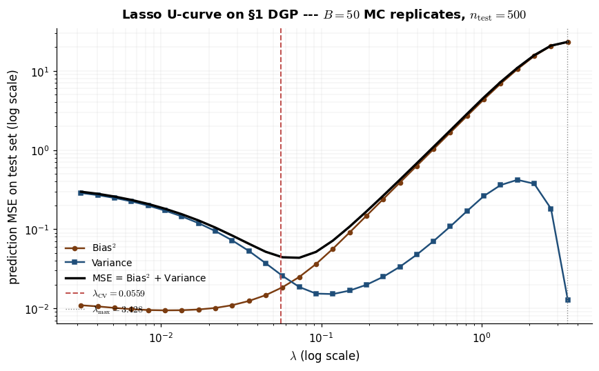

```python
# §4.3 — Empirical U-curve on DGP-1 via Monte Carlo.
# B replicate training sets, fixed test set, lasso path at each replicate,
# decompose prediction MSE on test into bias^2 + variance.

from sklearn.linear_model import lasso_path

# lambda_max for DGP-1 (using the §1 sample as a representative case).
lambda_max = float(np.max(np.abs(X1.T @ y1)) / X1.shape[0])
print(f"lambda_max for §1 sample: {lambda_max:.4f}")
print(f"lambda_CV for §1 sample:  {lam_cv:.4f}  (ratio lambda_CV/lambda_max = {lam_cv/lambda_max:.4f})")

# Setup: B = 50 MC replicates, decreasing lambda-grid for warm-start efficiency.
B_mc = 50
n_test = 500
lambda_grid = np.logspace(np.log10(lambda_max * 1.01), -2.5, 30)  # decreasing

# Fixed test set (held constant across MC replicates).
X_test, y_test, beta_star_mc, _ = make_dgp1(
    n=n_test, rng=np.random.default_rng(SEED + 300))
true_preds = X_test @ beta_star_mc

# Storage: predictions[b, k, i] = lasso prediction at test point i, replicate b, lambda-index k.
predictions = np.zeros((B_mc, len(lambda_grid), n_test))
for b in range(B_mc):
    X_train_b, y_train_b, _, _ = make_dgp1(rng=np.random.default_rng(SEED + 1000 + b))
    _, coefs, _ = lasso_path(X_train_b, y_train_b, alphas=lambda_grid,
                              tol=1e-7, max_iter=20_000)
    # coefs shape: (p, n_alphas). predictions[b] should be (n_alphas, n_test).
    predictions[b] = (X_test @ coefs).T

# Bias^2, variance, MSE.
mean_pred = predictions.mean(axis=0)                 # (n_lambda, n_test)
bias_sq   = np.mean((mean_pred - true_preds) ** 2, axis=1)
variance  = np.mean(predictions.var(axis=0), axis=1)
mse_total = bias_sq + variance

# Sanity: bias^2 monotonically decreases in lambda (= decreases along the
# array, since lambda_grid is decreasing). The MSE total should be U-shaped
# in lambda, with argmin in the interior. Variance is NOT monotonic in the
# n < p sparse regime — it is U-shaped on its own (small at very large lambda
# where beta_hat ~ 0; small in the lasso "sweet spot" where soft-thresholding
# stabilizes the support; large at very small lambda where the lasso
# approaches the non-unique OLS solution and variance explodes), so we do not
# assert variance monotonicity here. The variance trajectory itself is part
# of what Figure 4.1 below visualizes.
assert np.sum(np.diff(bias_sq) > 1e-3) <= 4, \
    "bias^2 should be (approximately) monotonically increasing in lambda"
mse_argmin = int(np.argmin(mse_total))
assert 0 < mse_argmin < len(mse_total) - 1, \
    "MSE should be U-shaped — argmin should sit in the interior of the lambda grid"

# Find empirical lambda-min.
lam_min_emp = lambda_grid[int(np.argmin(mse_total))]
print(f"\nEmpirical MSE-minimizing lambda from MC: {lam_min_emp:.4f}")
print(f"LassoCV-selected lambda from §1:         {lam_cv:.4f}")

# --- Figure 4.1 — U-curve ---
fig, ax = plt.subplots(figsize=(8.0, 5.0))
ax.plot(lambda_grid, bias_sq, "o-", color=COLOR_RIDGE,
        linewidth=1.6, markersize=4, label=r"Bias$^2$")
ax.plot(lambda_grid, variance, "s-", color=COLOR_LASSO,
        linewidth=1.6, markersize=4, label="Variance")
ax.plot(lambda_grid, mse_total, "-", color=COLOR_TRUTH,
        linewidth=2.2, label=r"MSE = Bias$^2$ + Variance")
ax.axvline(lam_cv, color=COLOR_DEBIASED, linewidth=1.3, linestyle="--",
           label=fr"$\lambda_{{\mathrm{{CV}}}} = {lam_cv:.4f}$")
ax.axvline(lambda_max, color="#888888", linewidth=0.9, linestyle=":",
           label=fr"$\lambda_{{\max}} = {lambda_max:.3f}$")
ax.set_xscale("log")
ax.set_yscale("log")
ax.set_xlabel(r"$\lambda$ (log scale)")
ax.set_ylabel(r"prediction MSE on test set (log scale)")
ax.set_title(f"Lasso U-curve on §1 DGP --- $B = {B_mc}$ MC replicates, $n_{{\\mathrm{{test}}}} = {n_test}$")
ax.legend(loc="lower left", fontsize=9)
ax.grid(True, which="both", linewidth=0.3, alpha=0.4)
fig.tight_layout()
fig.savefig(OUT_DIR / "fig_04_01_u_curve.png", bbox_inches="tight")
plt.show()
```

### §4.4 The lasso solution path is piecewise linear

The **lasso solution path** is the function $\lambda \mapsto \hat{\boldsymbol\beta}(\lambda)$ for $\lambda \in [0, \lambda_{\max}]$.

> **Theorem 4.1 (piecewise linearity; Efron-Hastie-Johnstone-Tibshirani 2004).** The lasso solution path $\hat{\boldsymbol\beta}(\lambda)$ is a continuous piecewise-linear function of $\lambda$. There is a finite sequence of **knots** $\lambda_{\max} = \lambda_{(0)} > \lambda_{(1)} > \dots > \lambda_{(K)} = 0$ such that on each interval $[\lambda_{(k+1)}, \lambda_{(k)}]$, the active set $\hat A_\lambda$ is constant and $\hat{\boldsymbol\beta}(\lambda)$ is linear in $\lambda$.

The proof is direct from KKT: on each interval where $\hat A_\lambda$ is fixed, the active condition $\frac{1}{n}\mathbf{X}_{\hat A}^\top(\mathbf{y} - \mathbf{X}\hat{\boldsymbol\beta}) = \lambda \, \mathrm{sign}(\hat{\boldsymbol\beta}_{\hat A})$ is a linear system in $\hat{\boldsymbol\beta}_{\hat A}$ with $\lambda$ on the right-hand side, so the solution is linear in $\lambda$. The LARS algorithm (Efron et al. 2004) traces this knot-by-knot in $O(np \min(n, p))$ total time; for moderate-to-large $p$ coordinate descent on a $\lambda$-grid is faster in practice.

**Reading the path.** Plotting $\hat\beta_j(\lambda)$ vs $\log \lambda$ for all $j$: as $\lambda$ decreases from $\lambda_{\max}$, the first coordinate to enter is $\arg\max_j |(\mathbf{X}^\top \mathbf{y} / n)_j|$ — the feature most correlated with the response. Subsequent coordinates enter at successively smaller $\lambda$, roughly in order of importance. A coordinate can also leave the active set (coefficient passes through zero), uncommon in continuous designs but possible.

```
Active coordinates at lambda ~ lambda_max: 0  (expect 0 or 1)
First 10 coords to enter the active set (and their entry lambda):
  j =   7  enters at lambda = 3.2288  * true active
  j =   4  enters at lambda = 3.0109  * true active
  j =   8  enters at lambda = 2.8077  * true active
  j =   5  enters at lambda = 2.8077  * true active
  j =   1  enters at lambda = 2.4415  * true active
  j =   2  enters at lambda = 2.4415  * true active
  j =   3  enters at lambda = 1.8461  * true active
  j =   6  enters at lambda = 1.7215  * true active
  j =   9  enters at lambda = 1.3018  * true active
  j =   0  enters at lambda = 1.0556  * true active
```

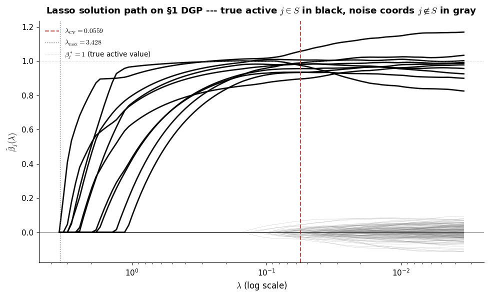

```python
# §4.4 — Lasso solution path on the §1 DGP.

# Compute the path on a fine lambda-grid, using sklearn's lasso_path with warm starts.
lambda_path = np.logspace(np.log10(lambda_max * 1.01), np.log10(lambda_max * 1e-3), 100)
_, path_coefs, _ = lasso_path(X1, y1, alphas=lambda_path,
                               tol=1e-8, max_iter=20_000)
# path_coefs shape: (p, n_lambda)

# Sanity: at lambda = lambda_max (largest in our grid), the solution should be all zeros
# (or have at most 1 active coefficient).
n_active_at_max = int(np.sum(np.abs(path_coefs[:, 0]) > 1e-10))
print(f"Active coordinates at lambda ~ lambda_max: {n_active_at_max}  (expect 0 or 1)")
assert n_active_at_max <= 1, "At lambda_max the lasso solution should be identically zero or have one active coord"

# Order in which coordinates enter the active set (smallest lambda at which |beta_hat_j| > 1e-10).
entry_lambda = np.full(X1.shape[1], np.nan)
for j in range(X1.shape[1]):
    nonzero = np.where(np.abs(path_coefs[j, :]) > 1e-10)[0]
    if len(nonzero) > 0:
        entry_lambda[j] = lambda_path[nonzero[0]]
order = np.argsort(-entry_lambda)  # decreasing lambda = first to enter
print("First 10 coords to enter the active set (and their entry lambda):")
for j in order[:10]:
    in_S = "* true active" if j < 10 else "  noise"
    print(f"  j = {j:>3d}  enters at lambda = {entry_lambda[j]:.4f}  {in_S}")

# --- Figure 4.2 — Solution path ---
fig, ax = plt.subplots(figsize=(9.0, 5.5))
# Inactive coords (j >= 10): light gray, thin lines.
for j in range(10, X1.shape[1]):
    ax.plot(lambda_path, path_coefs[j, :], color=COLOR_OLS,
            alpha=0.30, linewidth=0.5)
# Active coords (j in S = {0..9}): black, thick lines, labeled.
for j in range(10):
    ax.plot(lambda_path, path_coefs[j, :], color=COLOR_TRUTH,
            alpha=0.95, linewidth=1.8)

ax.axvline(lam_cv, color=COLOR_DEBIASED, linewidth=1.4, linestyle="--",
           label=fr"$\lambda_{{\mathrm{{CV}}}} = {lam_cv:.4f}$")
ax.axvline(lambda_max, color="#666666", linewidth=0.9, linestyle=":",
           label=fr"$\lambda_{{\max}} = {lambda_max:.3f}$")
ax.axhline(1.0, color="#aaaaaa", linewidth=0.7, linestyle=":",
           alpha=0.6, label=r"$\beta^*_j = 1$ (true active value)")
ax.axhline(0, color="black", linewidth=0.4)

ax.set_xscale("log")
ax.set_xlabel(r"$\lambda$ (log scale)")
ax.set_ylabel(r"$\hat\beta_j(\lambda)$")
ax.set_title("Lasso solution path on §1 DGP --- true active $j \\in S$ in black, "
             "noise coords $j \\notin S$ in gray")
ax.legend(loc="upper left", fontsize=9)
ax.invert_xaxis()  # convention: lambda decreasing left-to-right (more features as we move right)
fig.tight_layout()
fig.savefig(OUT_DIR / "fig_04_02_solution_path.png", bbox_inches="tight")
plt.show()
```

## §5. The lasso oracle inequality

This is the topic's headline theoretical result: under a restricted-eigenvalue condition on the design and a deviation bound on the noise, the lasso achieves prediction risk of order $\sigma^2 s \log(p) / n$ — comparable to what an oracle that knew the true active set $S$ in advance could achieve, up to a logarithmic factor in $p$. The bound is **non-asymptotic** (holds with high probability for any finite $n$, $p$), **dimension-free** (the dependence on $p$ is only logarithmic), and **rate-optimal** for sparse high-dimensional regression.

The proof has four steps and follows Bickel-Ritov-Tsybakov (2009). **Step 1 (the basic inequality)** uses the lasso's optimality to bound prediction error in terms of the L1 estimation error and a noise term. **Step 2 (the cone condition)** shows the error vector $\hat{\boldsymbol\beta} - \boldsymbol\beta^*$ has most of its L1 mass on $S$. **Step 3 (the restricted-eigenvalue condition)** lets us convert L1 estimation error on $S$ into a lower bound on the prediction error. **Step 4 (the deviation step)** controls the noise term using a maximal sub-Gaussian inequality.

### §5.1 Setup: prediction risk in the high-dim regime

Standard high-dimensional linear regression model: $\mathbf{y} = \mathbf{X} \boldsymbol\beta^* + \boldsymbol\varepsilon$, $\mathbf{X} \in \mathbb{R}^{n \times p}$, $\boldsymbol\beta^* \in \mathbb{R}^p$, $\boldsymbol\varepsilon \in \mathbb{R}^n$. Assumptions:

- **Sparsity:** $\boldsymbol\beta^*$ has support $S$ with $|S| = s$, $s \ll p$.
- **Sub-Gaussian noise:** independent $\varepsilon_i$ with sub-Gaussian parameter $\sigma$ ($\mathbb{E}[\exp(t\varepsilon_i)] \le \exp(t^2 \sigma^2/2)$). Gaussian noise is the canonical case.
- **Column-normalized design:** $\|\mathbf{X}_j\|_2^2 \le n$ for all $j$ (equivalently $(1/n)\|\mathbf{X}_j\|_2^2 \le 1$).

The **prediction risk** is $\mathrm{PE}(\hat{\boldsymbol\beta}) = (1/n) \|\mathbf{X}(\hat{\boldsymbol\beta} - \boldsymbol\beta^*)\|_2^2$ — the average squared in-sample prediction error against the true regression function.

The **oracle estimator** is OLS restricted to the (known) true support: $\hat{\boldsymbol\beta}^{\text{oracle}}_S = (\mathbf{X}_S^\top \mathbf{X}_S)^{-1} \mathbf{X}_S^\top \mathbf{y}$, $\hat{\boldsymbol\beta}^{\text{oracle}}_{S^c} = \mathbf{0}$. Its risk is $\sigma^2 s / n$ in expectation. The oracle inequality says the lasso achieves the same rate up to a $\log(p)$ factor — without knowing $S$.

### §5.2 The basic inequality

Starting point: lasso optimality, $\hat{\boldsymbol\beta}$ does no worse than $\boldsymbol\beta^*$:

$$ \tfrac{1}{2n}\|\mathbf{y} - \mathbf{X}\hat{\boldsymbol\beta}\|^2 + \lambda\|\hat{\boldsymbol\beta}\|_1 \le \tfrac{1}{2n}\|\mathbf{y} - \mathbf{X}\boldsymbol\beta^*\|^2 + \lambda\|\boldsymbol\beta^*\|_1. $$

Substitute $\mathbf{y} = \mathbf{X}\boldsymbol\beta^* + \boldsymbol\varepsilon$, let $\boldsymbol\delta = \hat{\boldsymbol\beta} - \boldsymbol\beta^*$, expand and cancel $(1/2n)\|\boldsymbol\varepsilon\|^2$:

$$ \tfrac{1}{n}\|\mathbf{X}\boldsymbol\delta\|^2 \le \tfrac{2}{n}\boldsymbol\varepsilon^\top \mathbf{X}\boldsymbol\delta + 2\lambda(\|\boldsymbol\beta^*\|_1 - \|\hat{\boldsymbol\beta}\|_1). \tag{$\star$} $$

**Control the noise term via Hölder.** $(2/n)|\boldsymbol\varepsilon^\top \mathbf{X}\boldsymbol\delta| \le 2 \|\mathbf{X}^\top\boldsymbol\varepsilon/n\|_\infty \cdot \|\boldsymbol\delta\|_1$. Define the **noise event** $\mathcal{E} = \{\|\mathbf{X}^\top\boldsymbol\varepsilon/n\|_\infty \le \lambda/2\}$. On $\mathcal{E}$, $(2/n)\boldsymbol\varepsilon^\top \mathbf{X}\boldsymbol\delta \le \lambda \|\boldsymbol\delta\|_1$.

**Control the L1-norm difference via the support split.** Decompose $\hat{\boldsymbol\beta} = \hat{\boldsymbol\beta}_S + \hat{\boldsymbol\beta}_{S^c}$. Since $\boldsymbol\beta^*_{S^c} = \mathbf{0}$:

$$ \|\boldsymbol\beta^*\|_1 - \|\hat{\boldsymbol\beta}\|_1 = \|\boldsymbol\beta^*_S\|_1 - \|\hat{\boldsymbol\beta}_S\|_1 - \|\hat{\boldsymbol\beta}_{S^c}\|_1 \le \|\boldsymbol\delta_S\|_1 - \|\boldsymbol\delta_{S^c}\|_1 $$

(reverse triangle on $\hat{\boldsymbol\beta}_S$ vs $\boldsymbol\beta^*_S$). Substitute everything into $(\star)$:

$$ \boxed{\;\tfrac{1}{n}\|\mathbf{X}\boldsymbol\delta\|^2 + \lambda \|\boldsymbol\delta_{S^c}\|_1 \le 3\lambda \|\boldsymbol\delta_S\|_1\;} \quad \text{on } \mathcal{E}. \tag{$\star\star$} $$

### §5.3 The cone condition

Drop the non-negative prediction-error term from $(\star\star)$:

$$ \boxed{\|\boldsymbol\delta_{S^c}\|_1 \le 3 \|\boldsymbol\delta_S\|_1.} $$

The error vector lies in the convex cone $\mathcal{C}(S, 3) := \{\boldsymbol\delta : \|\boldsymbol\delta_{S^c}\|_1 \le 3 \|\boldsymbol\delta_S\|_1\}$ — most of its L1 mass is on the true support.

This is the structural content of the basic inequality: without any further assumption on $\mathbf{X}$ or $\boldsymbol\varepsilon$ beyond $\mathcal{E}$, the lasso error is concentrated on $S$. Converting this into a rate bound requires a design assumption — the next step.

### §5.4 The restricted-eigenvalue condition

The basic inequality $(\star\star)$ gives $(1/n)\|\mathbf{X}\boldsymbol\delta\|^2 \le 3\lambda \|\boldsymbol\delta_S\|_1$. By Cauchy-Schwarz on $\boldsymbol\delta_S \in \mathbb{R}^s$, $\|\boldsymbol\delta_S\|_1 \le \sqrt{s} \|\boldsymbol\delta_S\|_2$. To convert this into a prediction-risk rate, we need a *lower bound* on $(1/n)\|\mathbf{X}\boldsymbol\delta\|^2$ in terms of $\|\boldsymbol\delta_S\|^2$.

> **Definition 5.1 (restricted-eigenvalue; Bickel-Ritov-Tsybakov 2009).** $\mathbf{X}$ satisfies $\mathrm{RE}(s, c_0)$ with constant $\kappa > 0$ if for every $\boldsymbol\delta \in \mathcal{C}(S, c_0)$ with $|S| \le s$, $$ \tfrac{1}{n}\|\mathbf{X}\boldsymbol\delta\|^2 \ge \kappa^2 \|\boldsymbol\delta_S\|_2^2. $$

In words: on the cone, the empirical Gram matrix $\mathbf{X}^\top\mathbf{X}/n$ acts like a positive-definite matrix on the active block, with smallest "restricted eigenvalue" at least $\kappa^2$. On the full $\mathbb{R}^p$ this would be $\lambda_{\min}(\mathbf{X}^\top\mathbf{X}/n) = 0$ when $p > n$; the cone restriction is what makes RE feasible in the high-dim regime.

**When does RE hold?**

- **Random Gaussian designs** with $\lambda_{\min}(\boldsymbol\Sigma) \ge \kappa_0^2$ and $n \gtrsim s\log(p)$: RE holds with $\kappa^2 \asymp \kappa_0^2$ w.h.p. (Raskutti-Wainwright-Yu 2010).
- **Sub-Gaussian designs:** same conclusion (Rudelson-Zhou 2013).
- **RIP $\Rightarrow$ RE** (Candès-Tao 2005; covered in §9).

For DGP-1 with AR(1) Toeplitz $\boldsymbol\Sigma$ and $\rho = 0.5$, $\lambda_{\min}(\boldsymbol\Sigma) \to (1-\rho)/(1+\rho) = 1/3$ as $p \to \infty$, so RE holds with $\kappa^2 \approx 1/3$.

### §5.5 The deviation step and the $O(\sigma^2 s \log p / n)$ rate

**Combining basic inequality and RE.** From $(\star\star)$ + Cauchy-Schwarz + RE:

$$ \tfrac{1}{n}\|\mathbf{X}\boldsymbol\delta\|^2 \le 3\lambda \sqrt{s}\|\boldsymbol\delta_S\|_2 \le \tfrac{3\lambda\sqrt{s}}{\kappa} \sqrt{\tfrac{1}{n}\|\mathbf{X}\boldsymbol\delta\|^2}. $$

Let $u = \sqrt{(1/n)\|\mathbf{X}\boldsymbol\delta\|^2}$. Then $u^2 \le 3\lambda\sqrt{s} u/\kappa$, so $u \le 3\lambda\sqrt{s}/\kappa$. Squaring:

$$ \tfrac{1}{n}\|\mathbf{X}(\hat{\boldsymbol\beta} - \boldsymbol\beta^*)\|^2 \le \tfrac{9\lambda^2 s}{\kappa^2} \quad \text{on } \mathcal{E} \cap \{\mathrm{RE}(s,3)\}. \tag{$\star\!\star\!\star$} $$

**The deviation step (sub-Gaussian maximal inequality).** For a single coordinate $j$, $(\mathbf{X}_j^\top \boldsymbol\varepsilon)/n$ is sub-Gaussian with parameter $\sigma_j^2 = \sigma^2 \|\mathbf{X}_j\|^2 / n^2 \le \sigma^2/n$. Sub-Gaussian tail + union bound over $p$ coords and 2 tails:

$$ \mathbb{P}\!\left(\|\mathbf{X}^\top\boldsymbol\varepsilon/n\|_\infty > t\right) \le 2p \exp(-nt^2/(2\sigma^2)). $$

Setting RHS = $\delta$: $t = \sigma\sqrt{2\log(2p/\delta)/n}$. Choose $\lambda = 2\sigma\sqrt{2\log(2p/\delta)/n}$ — then $\lambda/2 \ge \|\mathbf{X}^\top\boldsymbol\varepsilon/n\|_\infty$ on $\mathcal{E}$, which holds with probability $\ge 1 - \delta$.

> **Theorem 5.1 (lasso oracle inequality; Bickel-Ritov-Tsybakov 2009).** Assume $\boldsymbol\beta^*$ is $s$-sparse, the noise has independent sub-Gaussian entries with parameter $\sigma$, the columns satisfy $\|\mathbf{X}_j\|^2 \le n$, and the design satisfies $\mathrm{RE}(s, 3)$ with constant $\kappa > 0$. Choose $\lambda = 2\sigma\sqrt{2\log(2p/\delta)/n}$. Then with probability at least $1 - \delta$, $$ \tfrac{1}{n}\|\mathbf{X}(\hat{\boldsymbol\beta}^{\text{lasso}} - \boldsymbol\beta^*)\|^2 \le \tfrac{72 \sigma^2 s \log(2p/\delta)}{n \kappa^2}. $$

Setting $\delta = 1/p$, $\log(2p/\delta) = \log(2p^2) \le 2\log(2p)$, so the rate is $\sigma^2 s \log(p)/(n\kappa^2)$ — the **fundamental rate** for sparse high-dim regression. The $\log(p)$ factor is the price of not knowing $S$; the rate is minimax-optimal up to this $\log(p)$ factor.

```
AR(1) RE constant lower bound: kappa^2 ~ 0.3333
```

```
     n      emp risk     BRT bound   calib bound
    50        4.2689       67.1178        2.2681
   100        1.4582       33.5589        1.1340
   200        0.6339       16.7794        0.5670
   400        0.2948        8.3897        0.2835
   800        0.1418        4.1949        0.1418

Fitted slope of log(empirical risk) vs log(n): -1.213  (theory predicts -1)
```

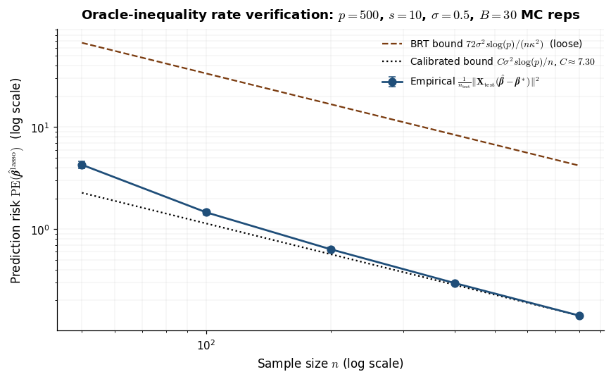

```python
# §5.5 — Numerical demonstration of the oracle-inequality rate.
# Hold p, s, sigma fixed; vary n; fit lasso at the theory-guided
# lambda = 2 * sigma * sqrt(2 log(p)/n); compute prediction risk on a fresh test set.
# Compare to the theoretical bound C * sigma^2 * s * log(p) / (n * kappa^2).

# Setup.
p_fix    = 500
s_fix    = 10
sigma_fx = 0.5
rho_fix  = 0.5
n_grid   = [50, 100, 200, 400, 800]
B_oi     = 30        # MC replicates per n
n_test_oi = 1000     # large test set for stable risk estimates

# RE constant lower bound: lambda_min(Sigma) -> (1 - rho)/(1 + rho) for AR(1) Sigma.
kappa_sq = (1 - rho_fix) / (1 + rho_fix)   # ~ 1/3 for rho=0.5
print(f"AR(1) RE constant lower bound: kappa^2 ~ {kappa_sq:.4f}")

emp_risk = np.zeros((len(n_grid), B_oi))
for i, n_train in enumerate(n_grid):
    # Theory-guided lambda for this n. delta = 1/p.
    lam_theory = 2 * sigma_fx * np.sqrt(2 * np.log(2 * p_fix / (1.0/p_fix)) / n_train)
    for b in range(B_oi):
        rng_b = np.random.default_rng(SEED + 5000 + 100*i + b)
        X_tr_oi, y_tr_oi, beta_star_oi, _ = make_dgp1(
            n=n_train, p=p_fix, s=s_fix, sigma=sigma_fx, rho=rho_fix, rng=rng_b)
        rng_te = np.random.default_rng(SEED + 6000 + 100*i + b)
        X_te_oi, _, _, _ = make_dgp1(
            n=n_test_oi, p=p_fix, s=s_fix, sigma=sigma_fx, rho=rho_fix, rng=rng_te)
        beta_hat = Lasso(alpha=lam_theory, fit_intercept=False, tol=1e-7,
                          max_iter=20_000).fit(X_tr_oi, y_tr_oi).coef_
        # Prediction risk: (1/n_test) ||X_test (beta_hat - beta*)||^2
        emp_risk[i, b] = float(np.mean((X_te_oi @ (beta_hat - beta_star_oi)) ** 2))

emp_risk_mean = emp_risk.mean(axis=1)
emp_risk_se   = emp_risk.std(axis=1, ddof=1) / np.sqrt(B_oi)

# Theoretical bound: C * sigma^2 * s * log(p) / (n * kappa^2) with C = 72 (BRT constant).
# We also plot a "calibrated" version with a smaller constant to show the slope match.
C_brt = 72.0
theory_brt = C_brt * sigma_fx**2 * s_fix * np.log(p_fix) / (np.array(n_grid) * kappa_sq)

# Calibrated constant: pick C so the bound passes through the empirical curve at the
# largest n. This shows the slope is correct even if BRT's C=72 is loose.
C_emp = emp_risk_mean[-1] * n_grid[-1] / (sigma_fx**2 * s_fix * np.log(p_fix))
theory_calibrated = C_emp * sigma_fx**2 * s_fix * np.log(p_fix) / np.array(n_grid)

print(f"\n{'n':>6}  {'emp risk':>12}  {'BRT bound':>12}  {'calib bound':>12}")
for i, n in enumerate(n_grid):
    print(f"{n:>6d}  {emp_risk_mean[i]:>12.4f}  {theory_brt[i]:>12.4f}  {theory_calibrated[i]:>12.4f}")

# Sanity: empirical risk should decrease as n grows, with slope close to -1 on log-log.
log_n = np.log(np.array(n_grid))
log_risk = np.log(emp_risk_mean)
slope, intercept = np.polyfit(log_n, log_risk, 1)
print(f"\nFitted slope of log(empirical risk) vs log(n): {slope:.3f}  (theory predicts -1)")
assert -1.5 < slope < -0.6, \
    f"Empirical slope should be near -1 (got {slope:.3f})"

# --- Figure 5.1: empirical risk vs theoretical bound, log-log axes ---
fig, ax = plt.subplots(figsize=(8.0, 5.0))
ax.errorbar(n_grid, emp_risk_mean, yerr=emp_risk_se, fmt="o-",
            color=COLOR_LASSO, linewidth=1.8, markersize=7, capsize=3,
            label=r"Empirical $\frac{1}{n_{\mathrm{test}}}\|\mathbf{X}_{\mathrm{test}}(\hat{\boldsymbol{\beta}} - \boldsymbol{\beta}^*)\|^2$")
ax.plot(n_grid, theory_brt, "--", color=COLOR_RIDGE, linewidth=1.5,
        label=fr"BRT bound $72 \sigma^2 s \log(p) / (n \kappa^2)$  (loose)")
ax.plot(n_grid, theory_calibrated, ":", color=COLOR_TRUTH, linewidth=1.5,
        label=fr"Calibrated bound $C \sigma^2 s \log(p)/n$, $C \approx {C_emp:.2f}$")
ax.set_xscale("log")
ax.set_yscale("log")
ax.set_xlabel(r"Sample size $n$ (log scale)")
ax.set_ylabel(r"Prediction risk $\mathrm{PE}(\hat{\boldsymbol{\beta}}^{\mathrm{lasso}})$  (log scale)")
ax.set_title(f"Oracle-inequality rate verification: $p={p_fix}$, $s={s_fix}$, $\\sigma={sigma_fx}$, "
             f"$B={B_oi}$ MC reps")
ax.legend(loc="upper right", fontsize=9)
ax.grid(True, which="both", linewidth=0.3, alpha=0.4)
fig.tight_layout()
fig.savefig(OUT_DIR / "fig_05_01_oracle_inequality_rate.png", bbox_inches="tight")
plt.show()
```

## §6. Variable-selection consistency

The §5 oracle inequality bounds the lasso's **prediction risk** — it predicts well, comparable to the oracle that knew $S$. It does **not** say the lasso correctly recovers $S$ itself. These are different statements with different sufficient conditions.

This section formalizes **sign-consistency** (the strongest form of support recovery), introduces the **irrepresentable condition** (Zhao-Yu 2006) that's both sufficient and essentially necessary for it, states the sample-size scaling, and contrasts the prediction-risk bound (RE-based) against the support-recovery bound (IC-based).

### §6.1 Sign-consistency: what it means and why prediction consistency doesn't imply it

Three increasingly strong support-recovery notions:

- **Support recovery:** $\hat A_\lambda := \{j : \hat\beta_j \neq 0\} = S$.
- **Sign consistency:** $\mathrm{sign}(\hat{\boldsymbol\beta}) = \mathrm{sign}(\boldsymbol\beta^*)$ — implies support recovery and gets the active-coefficient signs right.
- **Sign-consistent estimation:** $\mathbb{P}(\mathrm{sign}(\hat{\boldsymbol\beta}^{\text{lasso}}) = \mathrm{sign}(\boldsymbol\beta^*)) \to 1$ as $n \to \infty$.

**Why prediction consistency doesn't imply sign consistency.** Take $\mathbf{X}_1 = \mathbf{X}_2$ (perfectly collinear) with $\boldsymbol\beta^* = (1, 0)$. The lasso objective $\frac{1}{2n}\|\mathbf{y} - \mathbf{X}_1(\beta_1 + \beta_2)\|^2 + \lambda(|\beta_1| + |\beta_2|)$ depends on $(\beta_1, \beta_2)$ only through $\beta_1 + \beta_2$ and $|\beta_1| + |\beta_2|$. Many solutions: $(1, 0), (0, 1), (0.5, 0.5)$, etc. — identical prediction, dramatically different support.

This is extreme but the same phenomenon shows up whenever two features are highly correlated and both predictive — the lasso has no preference between them, may flip across resampled training sets.

### §6.2 The irrepresentable condition (Zhao-Yu 2006)

Given the active set $S$ and sign vector $\mathbf{s}^*_S := \mathrm{sign}(\boldsymbol\beta^*_S)$:

> **Definition 6.1 (irrepresentable condition).** The design $\mathbf{X}$ satisfies the **(weak) irrepresentable condition** for $(S, \mathbf{s}^*_S)$ if $$ \big\| \mathbf{X}_{S^c}^\top \mathbf{X}_S \big(\mathbf{X}_S^\top \mathbf{X}_S\big)^{-1} \mathbf{s}^*_S \big\|_\infty \;\le\; 1. $$ The **strong irrepresentable condition with parameter $\eta > 0$** strengthens this to $\le 1 - \eta$.

**Geometric interpretation.** Let $\mathbf{w}_j := (\mathbf{X}_S^\top \mathbf{X}_S)^{-1} \mathbf{X}_S^\top \mathbf{X}_j$ — the OLS coefficient vector for regressing the inactive feature $\mathbf{X}_j$ ($j \in S^c$) on the active features $\mathbf{X}_S$. Then IC reads $\max_{j \in S^c} |\mathbf{w}_j^\top \mathbf{s}^*_S| \le 1$.

Each $\mathbf{w}_j$ describes how the inactive feature $j$ is predicted by the active features. The IC asks: is the dot product of this prediction recipe with the sign pattern of active coefficients bounded by 1? If not — if some inactive feature is "too aligned" with the active features in a sign-coherent way — the lasso will select it in preference to the true active set.

For random $\mathbf{X}$ with iid rows from $\mathcal{N}(\mathbf{0}, \boldsymbol\Sigma)$, the empirical IC concentrates around the **population IC**: $\|\boldsymbol\Sigma_{S^c, S} \boldsymbol\Sigma_{S, S}^{-1} \mathbf{s}^*_S\|_\infty \le 1$. We compute this for DGP-1 across correlation strengths below.

```
DGP-1-style population IC crosses 1 at approximately rho ~ nan
  IC at rho=0.5 (DGP-1 default): 0.5000
  IC at rho=0.7:                0.7000
  IC at rho=0.9:                0.9000
```

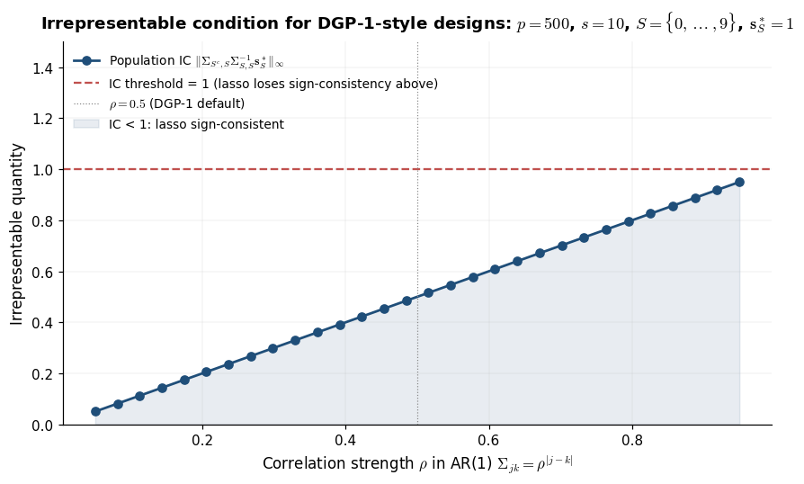

```python
# §6.2 — Population irrepresentable quantity for DGP-1-style designs.
# Sigma = AR(1) Toeplitz with parameter rho in [0, 0.95].
# Active set S = {0, ..., 9} contiguous, sign pattern s*_S = (+1,...,+1).
# Compute IC quantity ||Sigma_{S^c, S} Sigma_{S, S}^{-1} s*_S||_inf as a function of rho.

def population_ic(p, s, rho, sign_S):
    """Population irrepresentable quantity for AR(1) Toeplitz Sigma."""
    idx = np.arange(p)
    Sigma = rho ** np.abs(np.subtract.outer(idx, idx))
    S = np.arange(s)
    Sc = np.arange(s, p)
    Sigma_SS  = Sigma[np.ix_(S,  S)]
    Sigma_ScS = Sigma[np.ix_(Sc, S)]
    proj = Sigma_ScS @ np.linalg.solve(Sigma_SS, sign_S)
    return float(np.max(np.abs(proj)))

p_ic   = 500
s_ic   = 10
rho_grid = np.linspace(0.05, 0.95, 30)
ic_pop   = np.array([population_ic(p_ic, s_ic, rho, np.ones(s_ic))
                     for rho in rho_grid])

# Find the rho at which IC crosses 1 (linear interpolation).
above_one = np.where(ic_pop >= 1.0)[0]
if len(above_one) > 0:
    k = above_one[0]
    if k > 0:
        rho_crit = float(np.interp(1.0, [ic_pop[k-1], ic_pop[k]], [rho_grid[k-1], rho_grid[k]]))
    else:
        rho_crit = float(rho_grid[k])
else:
    rho_crit = float("nan")
print(f"DGP-1-style population IC crosses 1 at approximately rho ~ {rho_crit:.3f}")
print(f"  IC at rho=0.5 (DGP-1 default): {population_ic(p_ic, s_ic, 0.5, np.ones(s_ic)):.4f}")
print(f"  IC at rho=0.7:                {population_ic(p_ic, s_ic, 0.7, np.ones(s_ic)):.4f}")
print(f"  IC at rho=0.9:                {population_ic(p_ic, s_ic, 0.9, np.ones(s_ic)):.4f}")

# Sanity: IC should be monotonically increasing in rho for this DGP.
assert np.all(np.diff(ic_pop) > -1e-6), \
    "IC should be monotonically nondecreasing in rho for AR(1) Toeplitz Sigma"

# --- Figure 6.1 ---
fig, ax = plt.subplots(figsize=(8.0, 5.0))
ax.plot(rho_grid, ic_pop, "o-", color=COLOR_LASSO, linewidth=1.8, markersize=6,
        label=r"Population IC $\|\boldsymbol{\Sigma}_{S^c, S} \boldsymbol{\Sigma}_{S,S}^{-1} \mathbf{s}^*_S\|_\infty$")
ax.axhline(1.0, color=COLOR_DEBIASED, linewidth=1.5, linestyle="--",
           label=r"IC threshold = 1 (lasso loses sign-consistency above)")
ax.axvline(0.5, color="#888888", linewidth=0.8, linestyle=":",
           label=r"$\rho = 0.5$ (DGP-1 default)")
if not np.isnan(rho_crit):
    ax.axvline(rho_crit, color=COLOR_RIDGE, linewidth=1.0, linestyle=":",
               label=fr"crossover $\rho^* \approx {rho_crit:.2f}$")
# Shade the "lasso sign-consistent" region.
ax.fill_between(rho_grid, 0, ic_pop, where=(ic_pop <= 1.0),
                color=COLOR_LASSO, alpha=0.10, label="IC < 1: lasso sign-consistent")

ax.set_xlabel(r"Correlation strength $\rho$ in AR(1) $\boldsymbol{\Sigma}_{jk} = \rho^{|j-k|}$")
ax.set_ylabel("Irrepresentable quantity")
ax.set_title(f"Irrepresentable condition for DGP-1-style designs: $p = {p_ic}$, $s = {s_ic}$, "
             r"$S = \{0,\dots,9\}$, $\mathbf{s}^*_S = \mathbf{1}$")
ax.legend(loc="upper left", fontsize=9)
ax.grid(True, linewidth=0.3, alpha=0.4)
ax.set_ylim(0, max(1.5, ic_pop.max() * 1.05))
fig.tight_layout()
fig.savefig(OUT_DIR / "fig_06_01_irrepresentable_condition.png", bbox_inches="tight")
plt.show()
```